# Task 1: Data Loading, Cleaning & Exploratory Data Analysis

## 4.2 Why Initialisation Matters

Weight initialization plays an important role in training a neural network. If all weights are initialized to **zero**, every neuron in the same layer produces the same output, receives the same gradient, and updates in exactly the same way. This is called the **symmetry problem**, and it prevents the network from learning different features.

**Xavier (Glorot) Initialization** is designed for activation functions such as **Sigmoid** and **Tanh**. It keeps the variance of activations and gradients stable across layers, helping the network learn efficiently.

**He Initialization** is specially designed for **ReLU** activation. Since ReLU sets negative values to zero, about half of the neurons become inactive during each forward pass. He initialization compensates for this by using a larger variance, which helps maintain stable activations and improves convergence.

Therefore, choosing the correct initialization method improves learning speed, training stability, and overall model performance.

## 4.3 Convergence Speed Comparison Plot

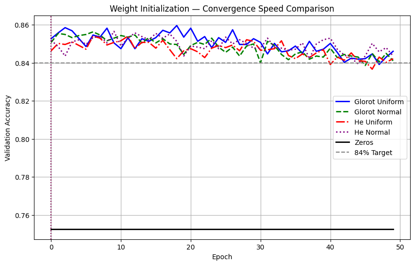

```python
# Store validation accuracy histories
histories = {
    "Glorot Uniform": history_glorot_uniform,
    "Glorot Normal": history_glorot_normal,
    "He Uniform": history_he_uniform,
    "He Normal": history_he_normal,
    "Zeros": history_zeros
}

plt.figure(figsize=(10,6))

colors = ["blue", "green", "red", "purple", "black"]
linestyles = ["-", "--", "-.", ":", "-"]

for (name, history), color, style in zip(histories.items(), colors, linestyles):

    val_acc = history.history["val_accuracy"]

    plt.plot(
        val_acc,
        label=name,
        color=color,
        linestyle=style,
        linewidth=2
    )

    # First epoch crossing 82%
    for epoch, acc in enumerate(val_acc):
        if acc >= 0.82:
            plt.axvline(
                x=epoch,
                color=color,
                linestyle=":",
                alpha=0.6
            )
            break

# Target Benchmark
plt.axhline(
    y=0.84,
    color="gray",
    linestyle="--",
    label="84% Target"
)

plt.title("Weight Initialization — Convergence Speed Comparison")
plt.xlabel("Epoch")
plt.ylabel("Validation Accuracy")
plt.legend()
plt.grid(True)
plt.show()
```

- The validation accuracy of all five initialization methods was compared.
- Vertical lines indicate the first epoch where a model reached **82% validation accuracy**.

## 4.4 Zeros Failure Demonstration

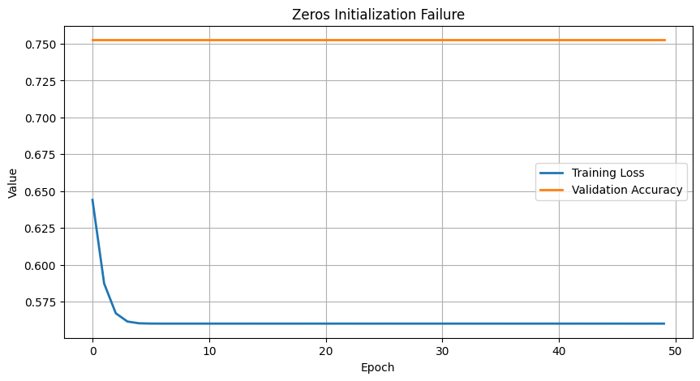

```python
plt.figure(figsize=(10,5))

# Training Loss
plt.plot(
    history_zeros.history["loss"],
    label="Training Loss",
    linewidth=2
)

# Validation Accuracy
plt.plot(
    history_zeros.history["val_accuracy"],
    label="Validation Accuracy",
    linewidth=2
)

plt.title("Zeros Initialization Failure")
plt.xlabel("Epoch")
plt.ylabel("Value")
plt.legend()
plt.grid(True)
plt.show()
```

## 4.5 Weight Distribution Visualisation

```python
# Build fresh models (before training)
model_glorot_before = build_ann(
    input_dim=X_train.shape[1],
    activation="relu",
    initializer="glorot_uniform"
)

model_he_before = build_ann(
    input_dim=X_train.shape[1],
    activation="relu",
    initializer="he_normal"
)

# Save Initial Weights
glorot_before = model_glorot_before.layers[0].get_weights()[0].flatten()
he_before = model_he_before.layers[0].get_weights()[0].flatten()
```

```python
# Extract Trained Weights
glorot_after = model_glorot_uniform.layers[0].get_weights()[0].flatten()
he_after = model_he_normal.layers[0].get_weights()[0].flatten()
```

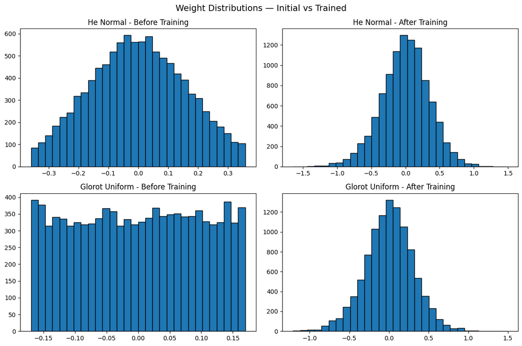

```python
plt.figure(figsize=(12,8))

# He Normal Before
plt.subplot(2,2,1)
plt.hist(he_before, bins=30, edgecolor="black")
plt.title("He Normal - Before Training")

# He Normal After
plt.subplot(2,2,2)
plt.hist(he_after, bins=30, edgecolor="black")
plt.title("He Normal - After Training")

# Glorot Uniform Before
plt.subplot(2,2,3)
plt.hist(glorot_before, bins=30, edgecolor="black")
plt.title("Glorot Uniform - Before Training")

# Glorot Uniform After
plt.subplot(2,2,4)
plt.hist(glorot_after, bins=30, edgecolor="black")
plt.title("Glorot Uniform - After Training")

plt.suptitle("Weight Distributions — Initial vs Trained", fontsize=14)
plt.tight_layout()
plt.show()
```

- The histograms compare the weight distributions before and after training.
- Initially, **Glorot Uniform** produces a relatively narrow and balanced distribution, while **He Normal** has a wider spread suitable for ReLU networks.
- After training, the weight distributions shift and spread because backpropagation updates the weights to learn meaningful patterns from the data.

# Task 5: Loss Functions

## 5.1 Binary Cross-Entropy – The Correct Loss Function

```python
# Confirm the loss function used in the baseline model
print("Baseline Loss Function:", model_base.loss)
```

```
Baseline Loss Function: binary_crossentropy
```

## Binary Cross-Entropy (BCE)

The baseline ANN model uses **Binary Cross-Entropy (BCE)** because this is a binary classification problem.

The Binary Cross-Entropy loss is:

$$ L = -\left( y \log(p) + (1-y)\log(1-p) \right) $$

Where:

- **y** = True label (0 or 1)
- **p** = Predicted probability from the Sigmoid output layer

BCE strongly penalizes confident incorrect predictions.

For example:

- If **y = 1** but **p = 0**, then **log(0) → -∞**, producing a very large loss.
- If **y = 0** but **p = 1**, the loss is also very large.

Therefore, Binary Cross-Entropy is the natural choice for binary classification because it measures how well the predicted probabilities match the true labels.

## 5.2 MSE as a Classification Loss – Wrong Tool Experiment

```python
# Build ANN using Mean Squared Error
model_mse = build_ann(
    input_dim=X_train.shape[1],
    activation="relu",
    initializer="he_normal",
    loss="mean_squared_error"
)

# Train Model
history_mse = model_mse.fit(
    X_train,
    y_train,
    epochs=50,
    batch_size=64,
    validation_split=0.1,
    verbose=1
)
```

```
509/509 ━━━━━━━━━━━━━━━━━━━━ 3s 3ms/step - accuracy: 0.8456 - loss: 0.1060 - val_accuracy: 0.8538 - val_loss: 0.1030
509/509 ━━━━━━━━━━━━━━━━━━━━ 1s 3ms/step - accuracy: 0.8540 - loss: 0.1008 - val_accuracy: 0.8519 - val_loss: 0.1036
509/509 ━━━━━━━━━━━━━━━━━━━━ 1s 3ms/step - accuracy: 0.8551 - loss: 0.0994 - val_accuracy: 0.8543 - val_loss: 0.1023
509/509 ━━━━━━━━━━━━━━━━━━━━ 4s 5ms/step - accuracy: 0.8576 - loss: 0.0979 - val_accuracy: 0.8502 - val_loss: 0.1027
509/509 ━━━━━━━━━━━━━━━━━━━━ 2s 3ms/step - accuracy: 0.8599 - loss: 0.0970 - val_accuracy: 0.8560 - val_loss: 0.1017
509/509 ━━━━━━━━━━━━━━━━━━━━ 1s 3ms/step - accuracy: 0.8620 - loss: 0.0960 - val_accuracy: 0.8546 - val_loss: 0.1017
509/509 ━━━━━━━━━━━━━━━━━━━━ 1s 3ms/step - accuracy: 0.8634 - loss: 0.0951 - val_accuracy: 0.8535 - val_loss: 0.1026
509/509 ━━━━━━━━━━━━━━━━━━━━ 1s 3ms/step - accuracy: 0.8648 - loss: 0.0940 - val_accuracy: 0.8532 - val_loss: 0.1020
509/509 ━━━━━━━━━━━━━━━━━━━━ 1s 3ms/step - accuracy: 0.8662 - loss: 0.0932 - val_accuracy: 0.8513 - val_loss: 0.1026
509/509 ━━━━━━━━━━━━━━━━━━━━ 1s 3ms/step - accuracy: 0.8671 - loss: 0.0923 - val_accuracy: 0.8530 - val_loss: 0.1035
509/509 ━━━━━━━━━━━━━━━━━━━━ 2s 3ms/step - accuracy: 0.8692 - loss: 0.0919 - val_accuracy: 0.8557 - val_loss: 0.1026
509/509 ━━━━━━━━━━━━━━━━━━━━ 2s 4ms/step - accuracy: 0.8709 - loss: 0.0910 - val_accuracy: 0.8494 - val_loss: 0.1039
509/509 ━━━━━━━━━━━━━━━━━━━━ 2s 4ms/step - accuracy: 0.8705 - loss: 0.0901 - val_accuracy: 0.8505 - val_loss: 0.1043
509/509 ━━━━━━━━━━━━━━━━━━━━ 1s 3ms/step - accuracy: 0.8712 - loss: 0.0898 - val_accuracy: 0.8507 - val_loss: 0.1028
509/509 ━━━━━━━━━━━━━━━━━━━━ 1s 3ms/step - accuracy: 0.8743 - loss: 0.0889 - val_accuracy: 0.8516 - val_loss: 0.1037
509/509 ━━━━━━━━━━━━━━━━━━━━ 1s 3ms/step - accuracy: 0.8742 - loss: 0.0884 - val_accuracy: 0.8483 - val_loss: 0.1037
509/509 ━━━━━━━━━━━━━━━━━━━━ 1s 3ms/step - accuracy: 0.8752 - loss: 0.0879 - val_accuracy: 0.8560 - val_loss: 0.1034
509/509 ━━━━━━━━━━━━━━━━━━━━ 1s 3ms/step - accuracy: 0.8760 - loss: 0.0873 - val_accuracy: 0.8541 - val_loss: 0.1033
509/509 ━━━━━━━━━━━━━━━━━━━━ 1s 3ms/step - accuracy: 0.8759 - loss: 0.0866 - val_accuracy: 0.8521 - val_loss: 0.1047
509/509 ━━━━━━━━━━━━━━━━━━━━ 1s 3ms/step - accuracy: 0.8797 - loss: 0.0860 - val_accuracy: 0.8557 - val_loss: 0.1035
509/509 ━━━━━━━━━━━━━━━━━━━━ 2s 4ms/step - accuracy: 0.8776 - loss: 0.0858 - val_accuracy: 0.8507 - val_loss: 0.1044
509/509 ━━━━━━━━━━━━━━━━━━━━ 2s 3ms/step - accuracy: 0.8792 - loss: 0.0849 - val_accuracy: 0.8524 - val_loss: 0.1038
509/509 ━━━━━━━━━━━━━━━━━━━━ 1s 3ms/step - accuracy: 0.8800 - loss: 0.0845 - val_accuracy: 0.8519 - val_loss: 0.1046
509/509 ━━━━━━━━━━━━━━━━━━━━ 1s 3ms/step - accuracy: 0.8787 - loss: 0.0842 - val_accuracy: 0.8452 - val_loss: 0.1053
509/509 ━━━━━━━━━━━━━━━━━━━━ 1s 3ms/step - accuracy: 0.8820 - loss: 0.0834 - val_accuracy: 0.8519 - val_loss: 0.1045
509/509 ━━━━━━━━━━━━━━━━━━━━ 1s 3ms/step - accuracy: 0.8824 - loss: 0.0832 - val_accuracy: 0.8469 - val_loss: 0.1067
509/509 ━━━━━━━━━━━━━━━━━━━━ 1s 3ms/step - accuracy: 0.8830 - loss: 0.0828 - val_accuracy: 0.8449 - val_loss: 0.1070
509/509 ━━━━━━━━━━━━━━━━━━━━ 1s 3ms/step - accuracy: 0.8836 - loss: 0.0824 - val_accuracy: 0.8463 - val_loss: 0.1075
509/509 ━━━━━━━━━━━━━━━━━━━━ 4s 5ms/step - accuracy: 0.8844 - loss: 0.0819 - val_accuracy: 0.8408 - val_loss: 0.1097
509/509 ━━━━━━━━━━━━━━━━━━━━ 2s 4ms/step - accuracy: 0.8853 - loss: 0.0812 - val_accuracy: 0.8458 - val_loss: 0.1067
509/509 ━━━━━━━━━━━━━━━━━━━━ 1s 3ms/step - accuracy: 0.8839 - loss: 0.0814 - val_accuracy: 0.8477 - val_loss: 0.1062
509/509 ━━━━━━━━━━━━━━━━━━━━ 1s 3ms/step - accuracy: 0.8854 - loss: 0.0807 - val_accuracy: 0.8441 - val_loss: 0.1075
509/509 ━━━━━━━━━━━━━━━━━━━━ 1s 3ms/step - accuracy: 0.8861 - loss: 0.0803 - val_accuracy: 0.8485 - val_loss: 0.1067
509/509 ━━━━━━━━━━━━━━━━━━━━ 1s 3ms/step - accuracy: 0.8887 - loss: 0.0798 - val_accuracy: 0.8458 - val_loss: 0.1081
509/509 ━━━━━━━━━━━━━━━━━━━━ 1s 3ms/step - accuracy: 0.8883 - loss: 0.0796 - val_accuracy: 0.8441 - val_loss: 0.1094
509/509 ━━━━━━━━━━━━━━━━━━━━ 1s 3ms/step - accuracy: 0.8891 - loss: 0.0790 - val_accuracy: 0.8455 - val_loss: 0.1092
509/509 ━━━━━━━━━━━━━━━━━━━━ 3s 4ms/step - accuracy: 0.8894 - loss: 0.0790 - val_accuracy: 0.8472 - val_loss: 0.1081
509/509 ━━━━━━━━━━━━━━━━━━━━ 2s 3ms/step - accuracy: 0.8881 - loss: 0.0786 - val_accuracy: 0.8449 - val_loss: 0.1095
509/509 ━━━━━━━━━━━━━━━━━━━━ 1s 3ms/step - accuracy: 0.8906 - loss: 0.0781 - val_accuracy: 0.8433 - val_loss: 0.1095
509/509 ━━━━━━━━━━━━━━━━━━━━ 1s 3ms/step - accuracy: 0.8912 - loss: 0.0781 - val_accuracy: 0.8494 - val_loss: 0.1082
509/509 ━━━━━━━━━━━━━━━━━━━━ 3s 3ms/step - accuracy: 0.8913 - loss: 0.0772 - val_accuracy: 0.8480 - val_loss: 0.1089
509/509 ━━━━━━━━━━━━━━━━━━━━ 1s 3ms/step - accuracy: 0.8914 - loss: 0.0772 - val_accuracy: 0.8452 - val_loss: 0.1103
509/509 ━━━━━━━━━━━━━━━━━━━━ 2s 4ms/step - accuracy: 0.8926 - loss: 0.0765 - val_accuracy: 0.8425 - val_loss: 0.1105
509/509 ━━━━━━━━━━━━━━━━━━━━ 2s 4ms/step - accuracy: 0.8934 - loss: 0.0763 - val_accuracy: 0.8449 - val_loss: 0.1090
509/509 ━━━━━━━━━━━━━━━━━━━━ 1s 3ms/step - accuracy: 0.8930 - loss: 0.0762 - val_accuracy: 0.8416 - val_loss: 0.1109
509/509 ━━━━━━━━━━━━━━━━━━━━ 1s 3ms/step - accuracy: 0.8936 - loss: 0.0760 - val_accuracy: 0.8438 - val_loss: 0.1111
509/509 ━━━━━━━━━━━━━━━━━━━━ 2s 3ms/step - accuracy: 0.8943 - loss: 0.0755 - val_accuracy: 0.8444 - val_loss: 0.1100
509/509 ━━━━━━━━━━━━━━━━━━━━ 1s 3ms/step - accuracy: 0.8945 - loss: 0.0751 - val_accuracy: 0.8419 - val_loss: 0.1104
509/509 ━━━━━━━━━━━━━━━━━━━━ 1s 3ms/step - accuracy: 0.8942 - loss: 0.0749 - val_accuracy: 0.8485 - val_loss: 0.1100
509/509 ━━━━━━━━━━━━━━━━━━━━ 1s 3ms/step - accuracy: 0.8955 - loss: 0.0746 - val_accuracy: 0.8441 - val_loss: 0.1120
```

```python
# Baseline Prediction
y_pred_base = (model_base.predict(X_test).flatten() > 0.5).astype(int)
f1_base = f1_score(y_test, y_pred_base)

# MSE Prediction
y_pred_mse = (model_mse.predict(X_test).flatten() > 0.5).astype(int)
f1_mse = f1_score(y_test, y_pred_mse)

print("Baseline F1 Score :", round(f1_base,4))
print("MSE Model F1 Score:", round(f1_mse,4))
```

```
283/283 ━━━━━━━━━━━━━━━━━━━━ 0s 1ms/step
283/283 ━━━━━━━━━━━━━━━━━━━━ 1s 2ms/step
Baseline F1 Score : 0.6706
MSE Model F1 Score: 0.6393
```

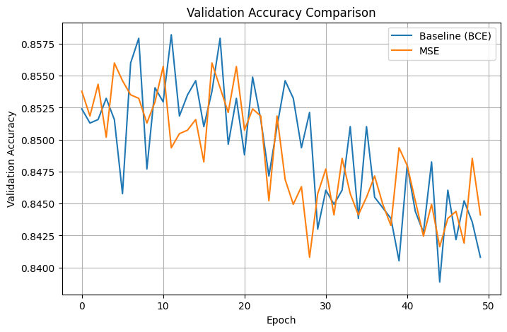

```python
plt.figure(figsize=(8,5))

plt.plot(history_base.history["val_accuracy"], label="Baseline (BCE)")

plt.plot(history_mse.history["val_accuracy"], label="MSE")

plt.title("Validation Accuracy Comparison")
plt.xlabel("Epoch")
plt.ylabel("Validation Accuracy")
plt.legend()
plt.grid(True)

plt.show()
```

## Why MSE is Not Suitable for Classification

Mean Squared Error (MSE) treats the output of the Sigmoid neuron as a regression value instead of a probability for classification.

Unlike Binary Cross-Entropy, MSE does not strongly penalize confident incorrect predictions. Its gradients also become very small when the Sigmoid output is close to **0** or **1**, slowing the learning process.

Binary Cross-Entropy has better gradient behavior for binary classification, allowing the network to learn faster and achieve better performance, especially on imbalanced datasets like the Adult Income dataset.

Therefore, **Binary Cross-Entropy is the preferred loss function for binary classification**, while **MSE is better suited for regression problems.**

## 5.3 Weighted Binary Cross-Entropy – Handling Class Imbalance

```python
from sklearn.utils.class_weight import compute_class_weight

# Compute Class Weights
classes = np.unique(y_train)

weights = compute_class_weight(
    class_weight="balanced",
    classes=classes,
    y=y_train
)

# Create Class Weight Dictionary
class_weight = {
    0: weights[0],
    1: weights[1]
}

print("Class Weights:")
print(class_weight)
```

```
Class Weights:
{0: np.float64(0.6647495498144133), 1: np.float64(2.0174548293553425)}
```

```python
# Build Model
model_wbce = build_ann(
    input_dim=X_train.shape[1],
    activation="relu",
    initializer="he_normal",
    loss="binary_crossentropy"
)

# Train with Class Weights
history_wbce = model_wbce.fit(
    X_train,
    y_train,
    epochs=50,
    batch_size=64,
    validation_split=0.1,
    class_weight=class_weight,
    verbose=1
)
```

```
509/509 ━━━━━━━━━━━━━━━━━━━━ 4s 4ms/step - accuracy: 0.7965 - loss: 0.4009 - val_accuracy: 0.7966 - val_loss: 0.3923
509/509 ━━━━━━━━━━━━━━━━━━━━ 2s 3ms/step - accuracy: 0.8074 - loss: 0.3727 - val_accuracy: 0.8134 - val_loss: 0.3771
509/509 ━━━━━━━━━━━━━━━━━━━━ 2s 3ms/step - accuracy: 0.8123 - loss: 0.3665 - val_accuracy: 0.7971 - val_loss: 0.3981
509/509 ━━━━━━━━━━━━━━━━━━━━ 1s 3ms/step - accuracy: 0.8158 - loss: 0.3621 - val_accuracy: 0.7872 - val_loss: 0.4104
509/509 ━━━━━━━━━━━━━━━━━━━━ 2s 3ms/step - accuracy: 0.8140 - loss: 0.3589 - val_accuracy: 0.8248 - val_loss: 0.3564
509/509 ━━━━━━━━━━━━━━━━━━━━ 1s 3ms/step - accuracy: 0.8179 - loss: 0.3547 - val_accuracy: 0.8217 - val_loss: 0.3559
509/509 ━━━━━━━━━━━━━━━━━━━━ 2s 4ms/step - accuracy: 0.8209 - loss: 0.3522 - val_accuracy: 0.8109 - val_loss: 0.3780
509/509 ━━━━━━━━━━━━━━━━━━━━ 2s 5ms/step - accuracy: 0.8228 - loss: 0.3485 - val_accuracy: 0.8079 - val_loss: 0.3879
509/509 ━━━━━━━━━━━━━━━━━━━━ 2s 3ms/step - accuracy: 0.8229 - loss: 0.3448 - val_accuracy: 0.8226 - val_loss: 0.3603
509/509 ━━━━━━━━━━━━━━━━━━━━ 2s 3ms/step - accuracy: 0.8243 - loss: 0.3417 - val_accuracy: 0.8107 - val_loss: 0.3767
509/509 ━━━━━━━━━━━━━━━━━━━━ 2s 3ms/step - accuracy: 0.8267 - loss: 0.3379 - val_accuracy: 0.8140 - val_loss: 0.3732
509/509 ━━━━━━━━━━━━━━━━━━━━ 1s 3ms/step - accuracy: 0.8281 - loss: 0.3358 - val_accuracy: 0.8134 - val_loss: 0.3764
509/509 ━━━━━━━━━━━━━━━━━━━━ 2s 3ms/step - accuracy: 0.8285 - loss: 0.3329 - val_accuracy: 0.8184 - val_loss: 0.3688
509/509 ━━━━━━━━━━━━━━━━━━━━ 1s 3ms/step - accuracy: 0.8288 - loss: 0.3291 - val_accuracy: 0.8355 - val_loss: 0.3448
509/509 ━━━━━━━━━━━━━━━━━━━━ 2s 5ms/step - accuracy: 0.8311 - loss: 0.3272 - val_accuracy: 0.8024 - val_loss: 0.3881
509/509 ━━━━━━━━━━━━━━━━━━━━ 2s 4ms/step - accuracy: 0.8322 - loss: 0.3237 - val_accuracy: 0.8187 - val_loss: 0.3760
509/509 ━━━━━━━━━━━━━━━━━━━━ 1s 3ms/step - accuracy: 0.8330 - loss: 0.3216 - val_accuracy: 0.7955 - val_loss: 0.4194
509/509 ━━━━━━━━━━━━━━━━━━━━ 2s 3ms/step - accuracy: 0.8345 - loss: 0.3185 - val_accuracy: 0.8109 - val_loss: 0.3839
509/509 ━━━━━━━━━━━━━━━━━━━━ 1s 3ms/step - accuracy: 0.8375 - loss: 0.3162 - val_accuracy: 0.7924 - val_loss: 0.4158
509/509 ━━━━━━━━━━━━━━━━━━━━ 2s 3ms/step - accuracy: 0.8368 - loss: 0.3137 - val_accuracy: 0.8217 - val_loss: 0.3649
509/509 ━━━━━━━━━━━━━━━━━━━━ 2s 3ms/step - accuracy: 0.8385 - loss: 0.3112 - val_accuracy: 0.8190 - val_loss: 0.3731
509/509 ━━━━━━━━━━━━━━━━━━━━ 2s 3ms/step - accuracy: 0.8389 - loss: 0.3086 - val_accuracy: 0.8126 - val_loss: 0.3886
509/509 ━━━━━━━━━━━━━━━━━━━━ 3s 5ms/step - accuracy: 0.8401 - loss: 0.3071 - val_accuracy: 0.8051 - val_loss: 0.3940
509/509 ━━━━━━━━━━━━━━━━━━━━ 2s 3ms/step - accuracy: 0.8413 - loss: 0.3058 - val_accuracy: 0.7869 - val_loss: 0.4239
509/509 ━━━━━━━━━━━━━━━━━━━━ 2s 3ms/step - accuracy: 0.8421 - loss: 0.3025 - val_accuracy: 0.8068 - val_loss: 0.4047
509/509 ━━━━━━━━━━━━━━━━━━━━ 2s 3ms/step - accuracy: 0.8411 - loss: 0.3005 - val_accuracy: 0.8212 - val_loss: 0.3840
509/509 ━━━━━━━━━━━━━━━━━━━━ 2s 3ms/step - accuracy: 0.8442 - loss: 0.2986 - val_accuracy: 0.7982 - val_loss: 0.4163
509/509 ━━━━━━━━━━━━━━━━━━━━ 1s 3ms/step - accuracy: 0.8449 - loss: 0.2966 - val_accuracy: 0.8118 - val_loss: 0.3907
509/509 ━━━━━━━━━━━━━━━━━━━━ 1s 3ms/step - accuracy: 0.8443 - loss: 0.2945 - val_accuracy: 0.8068 - val_loss: 0.4099
509/509 ━━━━━━━━━━━━━━━━━━━━ 2s 3ms/step - accuracy: 0.8463 - loss: 0.2913 - val_accuracy: 0.8170 - val_loss: 0.3905
509/509 ━━━━━━━━━━━━━━━━━━━━ 3s 5ms/step - accuracy: 0.8475 - loss: 0.2907 - val_accuracy: 0.7957 - val_loss: 0.4202
509/509 ━━━━━━━━━━━━━━━━━━━━ 2s 3ms/step - accuracy: 0.8462 - loss: 0.2894 - val_accuracy: 0.8090 - val_loss: 0.4048
509/509 ━━━━━━━━━━━━━━━━━━━━ 1s 3ms/step - accuracy: 0.8486 - loss: 0.2874 - val_accuracy: 0.8123 - val_loss: 0.3894
509/509 ━━━━━━━━━━━━━━━━━━━━ 2s 3ms/step - accuracy: 0.8494 - loss: 0.2858 - val_accuracy: 0.8145 - val_loss: 0.4052
509/509 ━━━━━━━━━━━━━━━━━━━━ 1s 3ms/step - accuracy: 0.8497 - loss: 0.2841 - val_accuracy: 0.8134 - val_loss: 0.3971
509/509 ━━━━━━━━━━━━━━━━━━━━ 1s 3ms/step - accuracy: 0.8513 - loss: 0.2820 - val_accuracy: 0.8032 - val_loss: 0.4134
509/509 ━━━━━━━━━━━━━━━━━━━━ 1s 3ms/step - accuracy: 0.8528 - loss: 0.2800 - val_accuracy: 0.8082 - val_loss: 0.4323
509/509 ━━━━━━━━━━━━━━━━━━━━ 1s 3ms/step - accuracy: 0.8518 - loss: 0.2792 - val_accuracy: 0.7993 - val_loss: 0.4275
509/509 ━━━━━━━━━━━━━━━━━━━━ 2s 4ms/step - accuracy: 0.8535 - loss: 0.2768 - val_accuracy: 0.7977 - val_loss: 0.4363
509/509 ━━━━━━━━━━━━━━━━━━━━ 2s 3ms/step - accuracy: 0.8514 - loss: 0.2772 - val_accuracy: 0.8121 - val_loss: 0.4219
509/509 ━━━━━━━━━━━━━━━━━━━━ 1s 3ms/step - accuracy: 0.8560 - loss: 0.2736 - val_accuracy: 0.8140 - val_loss: 0.4198
509/509 ━━━━━━━━━━━━━━━━━━━━ 1s 3ms/step - accuracy: 0.8533 - loss: 0.2738 - val_accuracy: 0.8126 - val_loss: 0.4181
509/509 ━━━━━━━━━━━━━━━━━━━━ 1s 3ms/step - accuracy: 0.8559 - loss: 0.2722 - val_accuracy: 0.8162 - val_loss: 0.4284
509/509 ━━━━━━━━━━━━━━━━━━━━ 1s 3ms/step - accuracy: 0.8576 - loss: 0.2704 - val_accuracy: 0.8096 - val_loss: 0.4373
509/509 ━━━━━━━━━━━━━━━━━━━━ 3s 3ms/step - accuracy: 0.8581 - loss: 0.2694 - val_accuracy: 0.8192 - val_loss: 0.4247
509/509 ━━━━━━━━━━━━━━━━━━━━ 2s 4ms/step - accuracy: 0.8577 - loss: 0.2682 - val_accuracy: 0.7991 - val_loss: 0.4559
509/509 ━━━━━━━━━━━━━━━━━━━━ 3s 4ms/step - accuracy: 0.8591 - loss: 0.2658 - val_accuracy: 0.8198 - val_loss: 0.4317
509/509 ━━━━━━━━━━━━━━━━━━━━ 2s 3ms/step - accuracy: 0.8579 - loss: 0.2664 - val_accuracy: 0.8087 - val_loss: 0.4411
509/509 ━━━━━━━━━━━━━━━━━━━━ 2s 3ms/step - accuracy: 0.8578 - loss: 0.2650 - val_accuracy: 0.7999 - val_loss: 0.4592
509/509 ━━━━━━━━━━━━━━━━━━━━ 2s 3ms/step - accuracy: 0.8601 - loss: 0.2632 - val_accuracy: 0.7913 - val_loss: 0.4908
```

```python
from sklearn.metrics import precision_score, recall_score, f1_score

# Baseline Predictions
y_pred_base = (model_base.predict(X_test).flatten() > 0.5).astype(int)

# Weighted BCE Predictions
y_pred_wbce = (model_wbce.predict(X_test).flatten() > 0.5).astype(int)

# Comparison Table
results = pd.DataFrame({
    "Model": ["Baseline BCE", "Weighted BCE"],
    "Precision": [
        precision_score(y_test, y_pred_base),
        precision_score(y_test, y_pred_wbce)
    ],
    "Recall": [
        recall_score(y_test, y_pred_base),
        recall_score(y_test, y_pred_wbce)
    ],
    "F1-Score": [
        f1_score(y_test, y_pred_base),
        f1_score(y_test, y_pred_wbce)
    ]
})

results
```

```
283/283 ━━━━━━━━━━━━━━━━━━━━ 0s 1ms/step
283/283 ━━━━━━━━━━━━━━━━━━━━ 1s 2ms/step
```

|  | Model | Precision | Recall | F1-Score |
| --- | --- | --- | --- | --- |
| 0 | Baseline BCE | 0.707426 | 0.637377 | 0.670577 |
| 1 | Weighted BCE | 0.544521 | 0.851026 | 0.664114 |

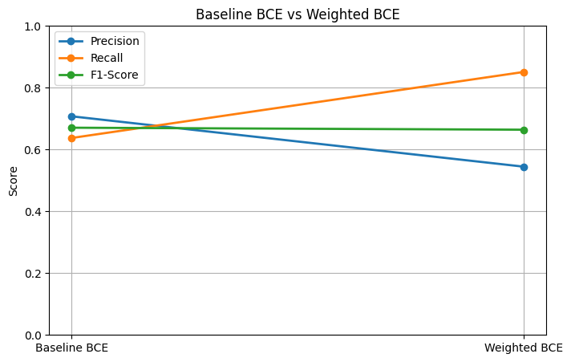

```python
metrics = ["Precision", "Recall", "F1-Score"]

plt.figure(figsize=(8,5))

for metric in metrics:
    plt.plot(
        results["Model"],
        results[metric],
        marker="o",
        linewidth=2,
        label=metric
    )

plt.title("Baseline BCE vs Weighted BCE")
plt.ylabel("Score")
plt.ylim(0, 1)
plt.grid(True)
plt.legend()
plt.show()
```

## Why Weighted Binary Cross-Entropy?

The Adult Income dataset is imbalanced because the number of **<=50K** samples is much larger than the number of **>50K** samples.

Weighted Binary Cross-Entropy assigns a **higher loss weight** to the minority class (>50K). This means that mistakes on minority-class samples are penalized more heavily during training.

Weighted BCE is useful when **missing a high-income individual is more costly than predicting a false positive**, making it suitable for imbalanced binary classification problems.

## 5.4 Focal Loss – Advanced Imbalance Handling

```python
def focal_loss(gamma=2.0, alpha=0.25):

    def loss(y_true, y_pred):

        y_pred = tf.clip_by_value(y_pred, 1e-7, 1 - 1e-7)

        bce = -(
            y_true * tf.math.log(y_pred) +
            (1 - y_true) * tf.math.log(1 - y_pred)
        )

        weight = (
            alpha * y_true * tf.pow(1 - y_pred, gamma) +
            (1 - alpha) * (1 - y_true) * tf.pow(y_pred, gamma)
        )

        return tf.reduce_mean(weight * bce)

    return loss
```

```python
model_focal = build_ann(
    input_dim=X_train.shape[1],
    activation="relu",
    initializer="he_normal",
    loss=focal_loss()
)

history_focal = model_focal.fit(
    X_train,
    y_train,
    epochs=50,
    batch_size=64,
    validation_split=0.1,
    verbose=1
)
```

```
509/509 ━━━━━━━━━━━━━━━━━━━━ 3s 4ms/step - accuracy: 0.8240 - loss: 0.0346 - val_accuracy: 0.8154 - val_loss: 0.0341
509/509 ━━━━━━━━━━━━━━━━━━━━ 2s 5ms/step - accuracy: 0.8295 - loss: 0.0327 - val_accuracy: 0.8284 - val_loss: 0.0336
509/509 ━━━━━━━━━━━━━━━━━━━━ 2s 4ms/step - accuracy: 0.8303 - loss: 0.0321 - val_accuracy: 0.8148 - val_loss: 0.0335
509/509 ━━━━━━━━━━━━━━━━━━━━ 1s 3ms/step - accuracy: 0.8335 - loss: 0.0318 - val_accuracy: 0.8284 - val_loss: 0.0333
509/509 ━━━━━━━━━━━━━━━━━━━━ 2s 3ms/step - accuracy: 0.8338 - loss: 0.0315 - val_accuracy: 0.8350 - val_loss: 0.0339
509/509 ━━━━━━━━━━━━━━━━━━━━ 2s 3ms/step - accuracy: 0.8365 - loss: 0.0311 - val_accuracy: 0.8195 - val_loss: 0.0328
509/509 ━━━━━━━━━━━━━━━━━━━━ 1s 3ms/step - accuracy: 0.8369 - loss: 0.0309 - val_accuracy: 0.8273 - val_loss: 0.0331
509/509 ━━━━━━━━━━━━━━━━━━━━ 1s 3ms/step - accuracy: 0.8376 - loss: 0.0305 - val_accuracy: 0.8350 - val_loss: 0.0332
509/509 ━━━━━━━━━━━━━━━━━━━━ 2s 3ms/step - accuracy: 0.8399 - loss: 0.0302 - val_accuracy: 0.8253 - val_loss: 0.0332
509/509 ━━━━━━━━━━━━━━━━━━━━ 2s 5ms/step - accuracy: 0.8399 - loss: 0.0300 - val_accuracy: 0.8380 - val_loss: 0.0346
509/509 ━━━━━━━━━━━━━━━━━━━━ 2s 3ms/step - accuracy: 0.8412 - loss: 0.0297 - val_accuracy: 0.8300 - val_loss: 0.0333
509/509 ━━━━━━━━━━━━━━━━━━━━ 2s 3ms/step - accuracy: 0.8439 - loss: 0.0294 - val_accuracy: 0.8162 - val_loss: 0.0330
509/509 ━━━━━━━━━━━━━━━━━━━━ 2s 3ms/step - accuracy: 0.8453 - loss: 0.0291 - val_accuracy: 0.8273 - val_loss: 0.0336
509/509 ━━━━━━━━━━━━━━━━━━━━ 2s 3ms/step - accuracy: 0.8464 - loss: 0.0288 - val_accuracy: 0.8239 - val_loss: 0.0339
509/509 ━━━━━━━━━━━━━━━━━━━━ 2s 3ms/step - accuracy: 0.8487 - loss: 0.0286 - val_accuracy: 0.8350 - val_loss: 0.0337
509/509 ━━━━━━━━━━━━━━━━━━━━ 2s 5ms/step - accuracy: 0.8485 - loss: 0.0283 - val_accuracy: 0.8292 - val_loss: 0.0338
509/509 ━━━━━━━━━━━━━━━━━━━━ 2s 4ms/step - accuracy: 0.8501 - loss: 0.0281 - val_accuracy: 0.8286 - val_loss: 0.0341
509/509 ━━━━━━━━━━━━━━━━━━━━ 2s 3ms/step - accuracy: 0.8498 - loss: 0.0277 - val_accuracy: 0.8328 - val_loss: 0.0346
509/509 ━━━━━━━━━━━━━━━━━━━━ 2s 3ms/step - accuracy: 0.8518 - loss: 0.0277 - val_accuracy: 0.8206 - val_loss: 0.0350
509/509 ━━━━━━━━━━━━━━━━━━━━ 2s 3ms/step - accuracy: 0.8522 - loss: 0.0273 - val_accuracy: 0.8353 - val_loss: 0.0354
509/509 ━━━━━━━━━━━━━━━━━━━━ 2s 3ms/step - accuracy: 0.8552 - loss: 0.0271 - val_accuracy: 0.8278 - val_loss: 0.0360
509/509 ━━━━━━━━━━━━━━━━━━━━ 2s 3ms/step - accuracy: 0.8540 - loss: 0.0269 - val_accuracy: 0.8336 - val_loss: 0.0361
509/509 ━━━━━━━━━━━━━━━━━━━━ 2s 3ms/step - accuracy: 0.8555 - loss: 0.0267 - val_accuracy: 0.8278 - val_loss: 0.0369
509/509 ━━━━━━━━━━━━━━━━━━━━ 2s 5ms/step - accuracy: 0.8579 - loss: 0.0265 - val_accuracy: 0.8239 - val_loss: 0.0365
509/509 ━━━━━━━━━━━━━━━━━━━━ 2s 4ms/step - accuracy: 0.8579 - loss: 0.0263 - val_accuracy: 0.8328 - val_loss: 0.0378
509/509 ━━━━━━━━━━━━━━━━━━━━ 2s 3ms/step - accuracy: 0.8594 - loss: 0.0261 - val_accuracy: 0.8256 - val_loss: 0.0371
509/509 ━━━━━━━━━━━━━━━━━━━━ 3s 3ms/step - accuracy: 0.8581 - loss: 0.0259 - val_accuracy: 0.8242 - val_loss: 0.0374
509/509 ━━━━━━━━━━━━━━━━━━━━ 2s 3ms/step - accuracy: 0.8600 - loss: 0.0258 - val_accuracy: 0.8342 - val_loss: 0.0391
509/509 ━━━━━━━━━━━━━━━━━━━━ 3s 3ms/step - accuracy: 0.8607 - loss: 0.0256 - val_accuracy: 0.8339 - val_loss: 0.0389
509/509 ━━━━━━━━━━━━━━━━━━━━ 2s 4ms/step - accuracy: 0.8631 - loss: 0.0254 - val_accuracy: 0.8364 - val_loss: 0.0409
509/509 ━━━━━━━━━━━━━━━━━━━━ 2s 4ms/step - accuracy: 0.8617 - loss: 0.0253 - val_accuracy: 0.8342 - val_loss: 0.0404
509/509 ━━━━━━━━━━━━━━━━━━━━ 2s 3ms/step - accuracy: 0.8625 - loss: 0.0255 - val_accuracy: 0.8361 - val_loss: 0.0401
509/509 ━━━━━━━━━━━━━━━━━━━━ 2s 3ms/step - accuracy: 0.8646 - loss: 0.0250 - val_accuracy: 0.8397 - val_loss: 0.0408
509/509 ━━━━━━━━━━━━━━━━━━━━ 3s 4ms/step - accuracy: 0.8645 - loss: 0.0248 - val_accuracy: 0.8300 - val_loss: 0.0405
509/509 ━━━━━━━━━━━━━━━━━━━━ 2s 3ms/step - accuracy: 0.8664 - loss: 0.0246 - val_accuracy: 0.8361 - val_loss: 0.0407
509/509 ━━━━━━━━━━━━━━━━━━━━ 2s 3ms/step - accuracy: 0.8660 - loss: 0.0247 - val_accuracy: 0.8350 - val_loss: 0.0412
509/509 ━━━━━━━━━━━━━━━━━━━━ 3s 5ms/step - accuracy: 0.8672 - loss: 0.0243 - val_accuracy: 0.8242 - val_loss: 0.0411
509/509 ━━━━━━━━━━━━━━━━━━━━ 2s 4ms/step - accuracy: 0.8681 - loss: 0.0243 - val_accuracy: 0.8203 - val_loss: 0.0427
509/509 ━━━━━━━━━━━━━━━━━━━━ 2s 3ms/step - accuracy: 0.8676 - loss: 0.0243 - val_accuracy: 0.8333 - val_loss: 0.0441
509/509 ━━━━━━━━━━━━━━━━━━━━ 2s 3ms/step - accuracy: 0.8694 - loss: 0.0240 - val_accuracy: 0.8292 - val_loss: 0.0430
509/509 ━━━━━━━━━━━━━━━━━━━━ 2s 3ms/step - accuracy: 0.8708 - loss: 0.0237 - val_accuracy: 0.8336 - val_loss: 0.0452
509/509 ━━━━━━━━━━━━━━━━━━━━ 2s 3ms/step - accuracy: 0.8705 - loss: 0.0237 - val_accuracy: 0.8378 - val_loss: 0.0453
509/509 ━━━━━━━━━━━━━━━━━━━━ 2s 3ms/step - accuracy: 0.8716 - loss: 0.0237 - val_accuracy: 0.8303 - val_loss: 0.0447
509/509 ━━━━━━━━━━━━━━━━━━━━ 3s 5ms/step - accuracy: 0.8712 - loss: 0.0235 - val_accuracy: 0.8375 - val_loss: 0.0478
509/509 ━━━━━━━━━━━━━━━━━━━━ 2s 4ms/step - accuracy: 0.8727 - loss: 0.0234 - val_accuracy: 0.8278 - val_loss: 0.0464
509/509 ━━━━━━━━━━━━━━━━━━━━ 2s 3ms/step - accuracy: 0.8726 - loss: 0.0233 - val_accuracy: 0.8306 - val_loss: 0.0468
509/509 ━━━━━━━━━━━━━━━━━━━━ 2s 3ms/step - accuracy: 0.8733 - loss: 0.0232 - val_accuracy: 0.8350 - val_loss: 0.0488
509/509 ━━━━━━━━━━━━━━━━━━━━ 2s 3ms/step - accuracy: 0.8741 - loss: 0.0232 - val_accuracy: 0.8231 - val_loss: 0.0472
509/509 ━━━━━━━━━━━━━━━━━━━━ 2s 3ms/step - accuracy: 0.8733 - loss: 0.0231 - val_accuracy: 0.8344 - val_loss: 0.0475
509/509 ━━━━━━━━━━━━━━━━━━━━ 2s 3ms/step - accuracy: 0.8755 - loss: 0.0227 - val_accuracy: 0.8320 - val_loss: 0.0495
```

```python
# Weighted BCE Prediction
y_pred_wbce = (model_wbce.predict(X_test).flatten() > 0.5).astype(int)

# Focal Loss Prediction
y_pred_focal = (model_focal.predict(X_test).flatten() > 0.5).astype(int)

comparison = pd.DataFrame({
    "Model": ["Weighted BCE", "Focal Loss"],
    "Recall": [
        recall_score(y_test, y_pred_wbce),
        recall_score(y_test, y_pred_focal)
    ],
    "F1-Score": [
        f1_score(y_test, y_pred_wbce),
        f1_score(y_test, y_pred_focal)
    ]
})

comparison
```

```
283/283 ━━━━━━━━━━━━━━━━━━━━ 0s 2ms/step
283/283 ━━━━━━━━━━━━━━━━━━━━ 1s 2ms/step
```

|  | Model | Recall | F1-Score |
| --- | --- | --- | --- |
| 0 | Weighted BCE | 0.851026 | 0.664114 |
| 1 | Focal Loss | 0.433988 | 0.553785 |

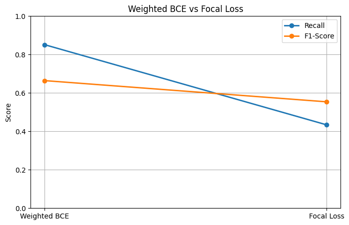

```python
metrics = ["Recall", "F1-Score"]

plt.figure(figsize=(8,5))

for metric in metrics:
    plt.plot(
        comparison["Model"],
        comparison[metric],
        marker="o",
        linewidth=2,
        label=metric
    )

plt.title("Weighted BCE vs Focal Loss")
plt.ylabel("Score")
plt.ylim(0, 1)
plt.grid(True)
plt.legend()

plt.show()
```

## Why Focal Loss?

Focal Loss was introduced by **Facebook AI (Lin et al., 2017)** to improve learning on highly imbalanced datasets.

Unlike Binary Cross-Entropy, Focal Loss reduces the contribution of **easy-to-classify samples** and focuses more on **hard, misclassified samples**.

The term **(1 − p)^γ** reduces the loss for correctly classified examples while increasing the importance of difficult examples. This allows the model to pay more attention to the minority class and often improves Recall and F1-score on imbalanced datasets.

## 5.5 Loss Function Summary Table

## Loss Function Comparison

[output not shown]

### Recommendation

- **Binary Cross-Entropy (BCE)** is the standard loss function for binary classification.
- **Weighted BCE** is recommended when the dataset is imbalanced because it gives more importance to the minority class.
- **Focal Loss** is the best choice for highly imbalanced datasets as it focuses training on hard-to-classify samples.
- **Mean Squared Error (MSE)** is not suitable for classification because it treats the problem like regression.

**Recommended Loss Function:** **Weighted BCE** (or **Focal Loss** if it achieves a higher F1-score on your results), as both are well suited for the Adult Income dataset with class imbalance.

# Task 6: Batch Normalization

## 6.1 Build ANN with Batch Normalization

```python
from tensorflow import keras
from tensorflow.keras.layers import Dense, BatchNormalization, Activation

# Build ANN with Batch Normalization
model_bn = keras.Sequential([

    Dense(
        128,
        kernel_initializer="he_normal",
        input_shape=(X_train.shape[1],)
    ),

    BatchNormalization(),
    Activation("relu"),

    Dense(
        64,
        kernel_initializer="he_normal"
    ),

    BatchNormalization(),
    Activation("relu"),

    Dense(1, activation="sigmoid")

])

# Compile Model
model_bn.compile(
    optimizer="adam",
    loss="binary_crossentropy",
    metrics=["accuracy"]
)

# Display Model Summary
model_bn.summary()
```

```
Model: "sequential_17"
```

```
┏━━━━━━━━━━━━━━━━━━━━━━━━━━━━━━━━━┳━━━━━━━━━━━━━━━━━━━━━━━━┳━━━━━━━━━━━━━━━┓
┃ Layer (type)                    ┃ Output Shape           ┃       Param # ┃
┡━━━━━━━━━━━━━━━━━━━━━━━━━━━━━━━━━╇━━━━━━━━━━━━━━━━━━━━━━━━╇━━━━━━━━━━━━━━━┩
│ dense_51 (Dense)                │ (None, 128)            │        10,368 │
├─────────────────────────────────┼────────────────────────┼───────────────┤
│ batch_normalization             │ (None, 128)            │           512 │
│ (BatchNormalization)            │                        │               │
├─────────────────────────────────┼────────────────────────┼───────────────┤
│ activation (Activation)         │ (None, 128)            │             0 │
├─────────────────────────────────┼────────────────────────┼───────────────┤
│ dense_52 (Dense)                │ (None, 64)             │         8,256 │
├─────────────────────────────────┼────────────────────────┼───────────────┤
│ batch_normalization_1           │ (None, 64)             │           256 │
│ (BatchNormalization)            │                        │               │
├─────────────────────────────────┼────────────────────────┼───────────────┤
│ activation_1 (Activation)       │ (None, 64)             │             0 │
├─────────────────────────────────┼────────────────────────┼───────────────┤
│ dense_53 (Dense)                │ (None, 1)              │            65 │
└─────────────────────────────────┴────────────────────────┴───────────────┘
```

```
 Total params: 19,457 (76.00 KB)
```

```
 Trainable params: 19,073 (74.50 KB)
```

```
 Non-trainable params: 384 (1.50 KB)
```

```python
history_bn = model_bn.fit(
    X_train,
    y_train,
    epochs=50,
    batch_size=64,
    validation_split=0.1,
    verbose=1
)
```

```
509/509 ━━━━━━━━━━━━━━━━━━━━ 5s 4ms/step - accuracy: 0.8321 - loss: 0.3543 - val_accuracy: 0.8496 - val_loss: 0.3253
509/509 ━━━━━━━━━━━━━━━━━━━━ 2s 3ms/step - accuracy: 0.8515 - loss: 0.3201 - val_accuracy: 0.8566 - val_loss: 0.3214
509/509 ━━━━━━━━━━━━━━━━━━━━ 2s 4ms/step - accuracy: 0.8532 - loss: 0.3134 - val_accuracy: 0.8549 - val_loss: 0.3214
509/509 ━━━━━━━━━━━━━━━━━━━━ 2s 4ms/step - accuracy: 0.8549 - loss: 0.3109 - val_accuracy: 0.8579 - val_loss: 0.3217
509/509 ━━━━━━━━━━━━━━━━━━━━ 2s 4ms/step - accuracy: 0.8559 - loss: 0.3069 - val_accuracy: 0.8524 - val_loss: 0.3223
509/509 ━━━━━━━━━━━━━━━━━━━━ 3s 5ms/step - accuracy: 0.8574 - loss: 0.3048 - val_accuracy: 0.8488 - val_loss: 0.3221
509/509 ━━━━━━━━━━━━━━━━━━━━ 2s 4ms/step - accuracy: 0.8592 - loss: 0.3037 - val_accuracy: 0.8585 - val_loss: 0.3206
509/509 ━━━━━━━━━━━━━━━━━━━━ 2s 4ms/step - accuracy: 0.8609 - loss: 0.3005 - val_accuracy: 0.8574 - val_loss: 0.3222
509/509 ━━━━━━━━━━━━━━━━━━━━ 2s 3ms/step - accuracy: 0.8598 - loss: 0.2992 - val_accuracy: 0.8549 - val_loss: 0.3256
509/509 ━━━━━━━━━━━━━━━━━━━━ 2s 4ms/step - accuracy: 0.8606 - loss: 0.2963 - val_accuracy: 0.8557 - val_loss: 0.3227
509/509 ━━━━━━━━━━━━━━━━━━━━ 2s 4ms/step - accuracy: 0.8611 - loss: 0.2956 - val_accuracy: 0.8538 - val_loss: 0.3244
509/509 ━━━━━━━━━━━━━━━━━━━━ 3s 5ms/step - accuracy: 0.8626 - loss: 0.2951 - val_accuracy: 0.8527 - val_loss: 0.3217
509/509 ━━━━━━━━━━━━━━━━━━━━ 4s 4ms/step - accuracy: 0.8634 - loss: 0.2924 - val_accuracy: 0.8549 - val_loss: 0.3217
509/509 ━━━━━━━━━━━━━━━━━━━━ 2s 4ms/step - accuracy: 0.8641 - loss: 0.2911 - val_accuracy: 0.8505 - val_loss: 0.3272
509/509 ━━━━━━━━━━━━━━━━━━━━ 2s 4ms/step - accuracy: 0.8648 - loss: 0.2902 - val_accuracy: 0.8460 - val_loss: 0.3253
509/509 ━━━━━━━━━━━━━━━━━━━━ 2s 4ms/step - accuracy: 0.8661 - loss: 0.2883 - val_accuracy: 0.8549 - val_loss: 0.3205
509/509 ━━━━━━━━━━━━━━━━━━━━ 3s 6ms/step - accuracy: 0.8666 - loss: 0.2871 - val_accuracy: 0.8513 - val_loss: 0.3266
509/509 ━━━━━━━━━━━━━━━━━━━━ 2s 4ms/step - accuracy: 0.8670 - loss: 0.2869 - val_accuracy: 0.8521 - val_loss: 0.3258
509/509 ━━━━━━━━━━━━━━━━━━━━ 2s 4ms/step - accuracy: 0.8674 - loss: 0.2824 - val_accuracy: 0.8560 - val_loss: 0.3254
509/509 ━━━━━━━━━━━━━━━━━━━━ 2s 4ms/step - accuracy: 0.8679 - loss: 0.2837 - val_accuracy: 0.8496 - val_loss: 0.3271
509/509 ━━━━━━━━━━━━━━━━━━━━ 2s 4ms/step - accuracy: 0.8679 - loss: 0.2813 - val_accuracy: 0.8543 - val_loss: 0.3282
509/509 ━━━━━━━━━━━━━━━━━━━━ 2s 4ms/step - accuracy: 0.8684 - loss: 0.2802 - val_accuracy: 0.8516 - val_loss: 0.3281
509/509 ━━━━━━━━━━━━━━━━━━━━ 3s 5ms/step - accuracy: 0.8695 - loss: 0.2792 - val_accuracy: 0.8499 - val_loss: 0.3310
509/509 ━━━━━━━━━━━━━━━━━━━━ 4s 3ms/step - accuracy: 0.8697 - loss: 0.2778 - val_accuracy: 0.8519 - val_loss: 0.3286
509/509 ━━━━━━━━━━━━━━━━━━━━ 2s 4ms/step - accuracy: 0.8700 - loss: 0.2782 - val_accuracy: 0.8524 - val_loss: 0.3284
509/509 ━━━━━━━━━━━━━━━━━━━━ 2s 3ms/step - accuracy: 0.8705 - loss: 0.2766 - val_accuracy: 0.8510 - val_loss: 0.3294
509/509 ━━━━━━━━━━━━━━━━━━━━ 2s 4ms/step - accuracy: 0.8721 - loss: 0.2741 - val_accuracy: 0.8474 - val_loss: 0.3332
509/509 ━━━━━━━━━━━━━━━━━━━━ 2s 5ms/step - accuracy: 0.8714 - loss: 0.2745 - val_accuracy: 0.8491 - val_loss: 0.3327
509/509 ━━━━━━━━━━━━━━━━━━━━ 3s 5ms/step - accuracy: 0.8723 - loss: 0.2723 - val_accuracy: 0.8524 - val_loss: 0.3339
509/509 ━━━━━━━━━━━━━━━━━━━━ 2s 4ms/step - accuracy: 0.8712 - loss: 0.2735 - val_accuracy: 0.8469 - val_loss: 0.3341
509/509 ━━━━━━━━━━━━━━━━━━━━ 2s 4ms/step - accuracy: 0.8720 - loss: 0.2707 - val_accuracy: 0.8494 - val_loss: 0.3318
509/509 ━━━━━━━━━━━━━━━━━━━━ 2s 4ms/step - accuracy: 0.8738 - loss: 0.2689 - val_accuracy: 0.8510 - val_loss: 0.3350
509/509 ━━━━━━━━━━━━━━━━━━━━ 2s 4ms/step - accuracy: 0.8732 - loss: 0.2679 - val_accuracy: 0.8477 - val_loss: 0.3411
509/509 ━━━━━━━━━━━━━━━━━━━━ 2s 3ms/step - accuracy: 0.8746 - loss: 0.2674 - val_accuracy: 0.8502 - val_loss: 0.3398
509/509 ━━━━━━━━━━━━━━━━━━━━ 3s 5ms/step - accuracy: 0.8755 - loss: 0.2669 - val_accuracy: 0.8469 - val_loss: 0.3446
509/509 ━━━━━━━━━━━━━━━━━━━━ 4s 4ms/step - accuracy: 0.8742 - loss: 0.2663 - val_accuracy: 0.8488 - val_loss: 0.3405
509/509 ━━━━━━━━━━━━━━━━━━━━ 2s 4ms/step - accuracy: 0.8766 - loss: 0.2659 - val_accuracy: 0.8411 - val_loss: 0.3450
509/509 ━━━━━━━━━━━━━━━━━━━━ 2s 3ms/step - accuracy: 0.8763 - loss: 0.2651 - val_accuracy: 0.8472 - val_loss: 0.3456
509/509 ━━━━━━━━━━━━━━━━━━━━ 2s 3ms/step - accuracy: 0.8767 - loss: 0.2649 - val_accuracy: 0.8521 - val_loss: 0.3416
509/509 ━━━━━━━━━━━━━━━━━━━━ 2s 4ms/step - accuracy: 0.8779 - loss: 0.2633 - val_accuracy: 0.8496 - val_loss: 0.3442
509/509 ━━━━━━━━━━━━━━━━━━━━ 3s 5ms/step - accuracy: 0.8753 - loss: 0.2644 - val_accuracy: 0.8494 - val_loss: 0.3467
509/509 ━━━━━━━━━━━━━━━━━━━━ 2s 3ms/step - accuracy: 0.8769 - loss: 0.2626 - val_accuracy: 0.8496 - val_loss: 0.3443
509/509 ━━━━━━━━━━━━━━━━━━━━ 2s 4ms/step - accuracy: 0.8766 - loss: 0.2612 - val_accuracy: 0.8488 - val_loss: 0.3424
509/509 ━━━━━━━━━━━━━━━━━━━━ 2s 4ms/step - accuracy: 0.8778 - loss: 0.2622 - val_accuracy: 0.8516 - val_loss: 0.3407
509/509 ━━━━━━━━━━━━━━━━━━━━ 2s 4ms/step - accuracy: 0.8785 - loss: 0.2582 - val_accuracy: 0.8477 - val_loss: 0.3471
509/509 ━━━━━━━━━━━━━━━━━━━━ 2s 4ms/step - accuracy: 0.8779 - loss: 0.2583 - val_accuracy: 0.8507 - val_loss: 0.3504
509/509 ━━━━━━━━━━━━━━━━━━━━ 4s 6ms/step - accuracy: 0.8773 - loss: 0.2577 - val_accuracy: 0.8549 - val_loss: 0.3489
509/509 ━━━━━━━━━━━━━━━━━━━━ 2s 4ms/step - accuracy: 0.8769 - loss: 0.2586 - val_accuracy: 0.8472 - val_loss: 0.3487
509/509 ━━━━━━━━━━━━━━━━━━━━ 3s 4ms/step - accuracy: 0.8785 - loss: 0.2569 - val_accuracy: 0.8502 - val_loss: 0.3527
509/509 ━━━━━━━━━━━━━━━━━━━━ 2s 4ms/step - accuracy: 0.8794 - loss: 0.2578 - val_accuracy: 0.8494 - val_loss: 0.3505
```

- An ANN model was built using **Batch Normalization** after each hidden Dense layer.
- The layer order is **Dense → Batch Normalization → ReLU Activation**.

## 6.2 Why Batch Normalization Matters

## Why Batch Normalization?

During training, the weights of each layer are continuously updated. As a result, the distribution of inputs to the next layer also changes. This is known as **Internal Covariate Shift**, which makes training slower and more difficult.

**Batch Normalization** solves this by normalizing the inputs of each mini-batch to have approximately **zero mean** and **unit variance**. After normalization, it applies two learnable parameters:

- **γ (Gamma):** Learns the optimal scale.
- **β (Beta):** Learns the optimal shift.

The Batch Normalization equation is:

$$ \text{BN}(x) = \gamma \left( \frac{x - \mu_B}{\sqrt{\sigma_B^2 + \varepsilon}} \right) + \beta $$

where:

- **μB** = Batch Mean
- **σ²B** = Batch Variance
- **ε** = Small constant for numerical stability

During inference (testing), Batch Normalization uses the **running mean** and **running variance** collected during training instead of the current batch statistics.

### Benefits of Batch Normalization

- Faster convergence during training.
- More stable gradients.
- Less sensitive to learning rate.
- Reduces internal covariate shift.
- Provides a small regularization effect, which can improve generalization.

## 6.3 Train and Compare: With vs Without Batch Normalization

```python
from sklearn.metrics import accuracy_score, f1_score

# Baseline Model Prediction
y_pred_base = (model_base.predict(X_test).flatten() > 0.5).astype(int);

# BatchNorm Model Prediction
y_pred_bn = (model_bn.predict(X_test).flatten() > 0.5).astype(int);

print("Baseline ANN")
print("Accuracy :", round(accuracy_score(y_test, y_pred_base),4))
print("F1 Score :", round(f1_score(y_test, y_pred_base),4))

print("\nBatchNorm ANN")
print("Accuracy :", round(accuracy_score(y_test, y_pred_bn),4))
print("F1 Score :", round(f1_score(y_test, y_pred_bn),4))
```

```
283/283 ━━━━━━━━━━━━━━━━━━━━ 0s 1ms/step
283/283 ━━━━━━━━━━━━━━━━━━━━ 1s 2ms/step
Baseline ANN
Accuracy : 0.8448
F1 Score : 0.6706

BatchNorm ANN
Accuracy : 0.8427
F1 Score : 0.6513
```

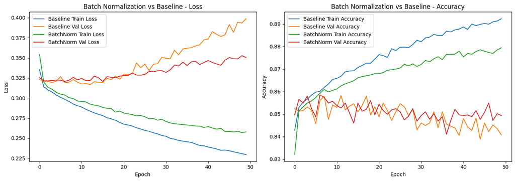

```python
plt.figure(figsize=(14,5))

# Loss
plt.subplot(1,2,1)

plt.plot(history_base.history["loss"], label="Baseline Train Loss")
plt.plot(history_base.history["val_loss"], label="Baseline Val Loss")

plt.plot(history_bn.history["loss"], label="BatchNorm Train Loss")
plt.plot(history_bn.history["val_loss"], label="BatchNorm Val Loss")

plt.title("Batch Normalization vs Baseline - Loss")
plt.xlabel("Epoch")
plt.ylabel("Loss")
plt.legend()

# Accuracy
plt.subplot(1,2,2)

plt.plot(history_base.history["accuracy"], label="Baseline Train Accuracy")
plt.plot(history_base.history["val_accuracy"], label="Baseline Val Accuracy")

plt.plot(history_bn.history["accuracy"], label="BatchNorm Train Accuracy")
plt.plot(history_bn.history["val_accuracy"], label="BatchNorm Val Accuracy")

plt.title("Batch Normalization vs Baseline - Accuracy")
plt.xlabel("Epoch")
plt.ylabel("Accuracy")
plt.legend()

plt.tight_layout()
plt.show()
```

- The Batch Normalization model was compared with the baseline ANN.
- Batch Normalization usually converges faster and shows a smaller gap between training and validation performance.

## 6.4 Batch Normalization Position Experiment

```python
model_bn_after = Sequential([
    Dense(128, kernel_initializer="he_normal", input_shape=(X_train.shape[1],)),
    Activation("relu"),
    BatchNormalization(),

    Dense(64, kernel_initializer="he_normal"),
    Activation("relu"),
    BatchNormalization(),

    Dense(1, activation="sigmoid")
])

model_bn_after.compile(
    optimizer="adam",
    loss="binary_crossentropy",
    metrics=["accuracy"]
)

history_bn_after = model_bn_after.fit(
    X_train,
    y_train,
    epochs=30,
    batch_size=64,
    validation_split=0.1,
    verbose=1
)
```

```
509/509 ━━━━━━━━━━━━━━━━━━━━ 5s 6ms/step - accuracy: 0.8327 - loss: 0.3695 - val_accuracy: 0.8447 - val_loss: 0.3357
509/509 ━━━━━━━━━━━━━━━━━━━━ 2s 4ms/step - accuracy: 0.8500 - loss: 0.3211 - val_accuracy: 0.8477 - val_loss: 0.3251
509/509 ━━━━━━━━━━━━━━━━━━━━ 2s 4ms/step - accuracy: 0.8540 - loss: 0.3139 - val_accuracy: 0.8474 - val_loss: 0.3289
509/509 ━━━━━━━━━━━━━━━━━━━━ 2s 4ms/step - accuracy: 0.8572 - loss: 0.3098 - val_accuracy: 0.8541 - val_loss: 0.3246
509/509 ━━━━━━━━━━━━━━━━━━━━ 2s 4ms/step - accuracy: 0.8557 - loss: 0.3070 - val_accuracy: 0.8485 - val_loss: 0.3244
509/509 ━━━━━━━━━━━━━━━━━━━━ 3s 5ms/step - accuracy: 0.8572 - loss: 0.3047 - val_accuracy: 0.8483 - val_loss: 0.3226
509/509 ━━━━━━━━━━━━━━━━━━━━ 3s 5ms/step - accuracy: 0.8575 - loss: 0.3020 - val_accuracy: 0.8541 - val_loss: 0.3266
509/509 ━━━━━━━━━━━━━━━━━━━━ 2s 4ms/step - accuracy: 0.8594 - loss: 0.2990 - val_accuracy: 0.8485 - val_loss: 0.3249
509/509 ━━━━━━━━━━━━━━━━━━━━ 2s 4ms/step - accuracy: 0.8607 - loss: 0.2985 - val_accuracy: 0.8499 - val_loss: 0.3272
509/509 ━━━━━━━━━━━━━━━━━━━━ 2s 4ms/step - accuracy: 0.8616 - loss: 0.2942 - val_accuracy: 0.8505 - val_loss: 0.3267
509/509 ━━━━━━━━━━━━━━━━━━━━ 2s 4ms/step - accuracy: 0.8633 - loss: 0.2929 - val_accuracy: 0.8480 - val_loss: 0.3294
509/509 ━━━━━━━━━━━━━━━━━━━━ 2s 4ms/step - accuracy: 0.8633 - loss: 0.2919 - val_accuracy: 0.8483 - val_loss: 0.3312
509/509 ━━━━━━━━━━━━━━━━━━━━ 3s 6ms/step - accuracy: 0.8652 - loss: 0.2892 - val_accuracy: 0.8519 - val_loss: 0.3267
509/509 ━━━━━━━━━━━━━━━━━━━━ 2s 4ms/step - accuracy: 0.8669 - loss: 0.2856 - val_accuracy: 0.8480 - val_loss: 0.3329
509/509 ━━━━━━━━━━━━━━━━━━━━ 2s 4ms/step - accuracy: 0.8655 - loss: 0.2855 - val_accuracy: 0.8502 - val_loss: 0.3337
509/509 ━━━━━━━━━━━━━━━━━━━━ 3s 4ms/step - accuracy: 0.8670 - loss: 0.2826 - val_accuracy: 0.8507 - val_loss: 0.3339
509/509 ━━━━━━━━━━━━━━━━━━━━ 2s 4ms/step - accuracy: 0.8677 - loss: 0.2820 - val_accuracy: 0.8488 - val_loss: 0.3425
509/509 ━━━━━━━━━━━━━━━━━━━━ 3s 5ms/step - accuracy: 0.8707 - loss: 0.2789 - val_accuracy: 0.8483 - val_loss: 0.3349
509/509 ━━━━━━━━━━━━━━━━━━━━ 3s 5ms/step - accuracy: 0.8682 - loss: 0.2787 - val_accuracy: 0.8494 - val_loss: 0.3349
509/509 ━━━━━━━━━━━━━━━━━━━━ 2s 4ms/step - accuracy: 0.8701 - loss: 0.2770 - val_accuracy: 0.8494 - val_loss: 0.3416
509/509 ━━━━━━━━━━━━━━━━━━━━ 2s 4ms/step - accuracy: 0.8712 - loss: 0.2746 - val_accuracy: 0.8474 - val_loss: 0.3404
509/509 ━━━━━━━━━━━━━━━━━━━━ 3s 4ms/step - accuracy: 0.8706 - loss: 0.2748 - val_accuracy: 0.8416 - val_loss: 0.3426
509/509 ━━━━━━━━━━━━━━━━━━━━ 2s 4ms/step - accuracy: 0.8719 - loss: 0.2727 - val_accuracy: 0.8460 - val_loss: 0.3410
509/509 ━━━━━━━━━━━━━━━━━━━━ 2s 4ms/step - accuracy: 0.8728 - loss: 0.2715 - val_accuracy: 0.8452 - val_loss: 0.3445
509/509 ━━━━━━━━━━━━━━━━━━━━ 3s 6ms/step - accuracy: 0.8732 - loss: 0.2705 - val_accuracy: 0.8516 - val_loss: 0.3422
509/509 ━━━━━━━━━━━━━━━━━━━━ 2s 4ms/step - accuracy: 0.8736 - loss: 0.2691 - val_accuracy: 0.8419 - val_loss: 0.3475
509/509 ━━━━━━━━━━━━━━━━━━━━ 2s 4ms/step - accuracy: 0.8756 - loss: 0.2677 - val_accuracy: 0.8483 - val_loss: 0.3437
509/509 ━━━━━━━━━━━━━━━━━━━━ 3s 7ms/step - accuracy: 0.8756 - loss: 0.2658 - val_accuracy: 0.8358 - val_loss: 0.3499
509/509 ━━━━━━━━━━━━━━━━━━━━ 2s 3ms/step - accuracy: 0.8748 - loss: 0.2636 - val_accuracy: 0.8427 - val_loss: 0.3542
509/509 ━━━━━━━━━━━━━━━━━━━━ 2s 5ms/step - accuracy: 0.8765 - loss: 0.2634 - val_accuracy: 0.8419 - val_loss: 0.3538
```

```python
model_bn_before = Sequential([
    Dense(128, kernel_initializer="he_normal", input_shape=(X_train.shape[1],)),
    BatchNormalization(),
    Activation("relu"),

    Dense(64, kernel_initializer="he_normal"),
    BatchNormalization(),
    Activation("relu"),

    Dense(1, activation="sigmoid")
])

model_bn_before.compile(
    optimizer="adam",
    loss="binary_crossentropy",
    metrics=["accuracy"]
)

history_bn_before = model_bn_before.fit(
    X_train,
    y_train,
    epochs=30,
    batch_size=64,
    validation_split=0.1,
    verbose=1
)
```

```
509/509 ━━━━━━━━━━━━━━━━━━━━ 5s 4ms/step - accuracy: 0.8369 - loss: 0.3487 - val_accuracy: 0.8463 - val_loss: 0.3259
509/509 ━━━━━━━━━━━━━━━━━━━━ 2s 4ms/step - accuracy: 0.8523 - loss: 0.3191 - val_accuracy: 0.8494 - val_loss: 0.3246
509/509 ━━━━━━━━━━━━━━━━━━━━ 2s 4ms/step - accuracy: 0.8546 - loss: 0.3146 - val_accuracy: 0.8449 - val_loss: 0.3259
509/509 ━━━━━━━━━━━━━━━━━━━━ 2s 4ms/step - accuracy: 0.8555 - loss: 0.3106 - val_accuracy: 0.8530 - val_loss: 0.3239
509/509 ━━━━━━━━━━━━━━━━━━━━ 2s 5ms/step - accuracy: 0.8579 - loss: 0.3078 - val_accuracy: 0.8527 - val_loss: 0.3200
509/509 ━━━━━━━━━━━━━━━━━━━━ 3s 5ms/step - accuracy: 0.8576 - loss: 0.3051 - val_accuracy: 0.8535 - val_loss: 0.3229
509/509 ━━━━━━━━━━━━━━━━━━━━ 2s 4ms/step - accuracy: 0.8594 - loss: 0.3010 - val_accuracy: 0.8530 - val_loss: 0.3278
509/509 ━━━━━━━━━━━━━━━━━━━━ 2s 4ms/step - accuracy: 0.8600 - loss: 0.3003 - val_accuracy: 0.8477 - val_loss: 0.3269
509/509 ━━━━━━━━━━━━━━━━━━━━ 2s 4ms/step - accuracy: 0.8613 - loss: 0.2998 - val_accuracy: 0.8480 - val_loss: 0.3244
509/509 ━━━━━━━━━━━━━━━━━━━━ 2s 4ms/step - accuracy: 0.8616 - loss: 0.2968 - val_accuracy: 0.8568 - val_loss: 0.3249
509/509 ━━━━━━━━━━━━━━━━━━━━ 2s 4ms/step - accuracy: 0.8624 - loss: 0.2940 - val_accuracy: 0.8488 - val_loss: 0.3295
509/509 ━━━━━━━━━━━━━━━━━━━━ 3s 6ms/step - accuracy: 0.8615 - loss: 0.2936 - val_accuracy: 0.8530 - val_loss: 0.3265
509/509 ━━━━━━━━━━━━━━━━━━━━ 4s 4ms/step - accuracy: 0.8628 - loss: 0.2897 - val_accuracy: 0.8535 - val_loss: 0.3269
509/509 ━━━━━━━━━━━━━━━━━━━━ 2s 4ms/step - accuracy: 0.8644 - loss: 0.2896 - val_accuracy: 0.8516 - val_loss: 0.3261
509/509 ━━━━━━━━━━━━━━━━━━━━ 2s 4ms/step - accuracy: 0.8655 - loss: 0.2878 - val_accuracy: 0.8483 - val_loss: 0.3285
509/509 ━━━━━━━━━━━━━━━━━━━━ 3s 4ms/step - accuracy: 0.8672 - loss: 0.2861 - val_accuracy: 0.8538 - val_loss: 0.3255
509/509 ━━━━━━━━━━━━━━━━━━━━ 3s 5ms/step - accuracy: 0.8650 - loss: 0.2843 - val_accuracy: 0.8499 - val_loss: 0.3263
509/509 ━━━━━━━━━━━━━━━━━━━━ 2s 4ms/step - accuracy: 0.8679 - loss: 0.2833 - val_accuracy: 0.8513 - val_loss: 0.3289
509/509 ━━━━━━━━━━━━━━━━━━━━ 2s 4ms/step - accuracy: 0.8669 - loss: 0.2838 - val_accuracy: 0.8485 - val_loss: 0.3261
509/509 ━━━━━━━━━━━━━━━━━━━━ 2s 3ms/step - accuracy: 0.8685 - loss: 0.2808 - val_accuracy: 0.8472 - val_loss: 0.3359
509/509 ━━━━━━━━━━━━━━━━━━━━ 2s 3ms/step - accuracy: 0.8689 - loss: 0.2789 - val_accuracy: 0.8444 - val_loss: 0.3311
509/509 ━━━━━━━━━━━━━━━━━━━━ 2s 3ms/step - accuracy: 0.8707 - loss: 0.2784 - val_accuracy: 0.8494 - val_loss: 0.3383
509/509 ━━━━━━━━━━━━━━━━━━━━ 4s 8ms/step - accuracy: 0.8710 - loss: 0.2769 - val_accuracy: 0.8491 - val_loss: 0.3345
509/509 ━━━━━━━━━━━━━━━━━━━━ 3s 4ms/step - accuracy: 0.8720 - loss: 0.2758 - val_accuracy: 0.8449 - val_loss: 0.3356
509/509 ━━━━━━━━━━━━━━━━━━━━ 2s 3ms/step - accuracy: 0.8716 - loss: 0.2745 - val_accuracy: 0.8513 - val_loss: 0.3375
509/509 ━━━━━━━━━━━━━━━━━━━━ 2s 4ms/step - accuracy: 0.8708 - loss: 0.2730 - val_accuracy: 0.8480 - val_loss: 0.3401
509/509 ━━━━━━━━━━━━━━━━━━━━ 2s 4ms/step - accuracy: 0.8731 - loss: 0.2728 - val_accuracy: 0.8507 - val_loss: 0.3395
509/509 ━━━━━━━━━━━━━━━━━━━━ 2s 4ms/step - accuracy: 0.8732 - loss: 0.2713 - val_accuracy: 0.8494 - val_loss: 0.3390
509/509 ━━━━━━━━━━━━━━━━━━━━ 3s 5ms/step - accuracy: 0.8741 - loss: 0.2703 - val_accuracy: 0.8477 - val_loss: 0.3343
509/509 ━━━━━━━━━━━━━━━━━━━━ 2s 4ms/step - accuracy: 0.8725 - loss: 0.2700 - val_accuracy: 0.8480 - val_loss: 0.3412
```

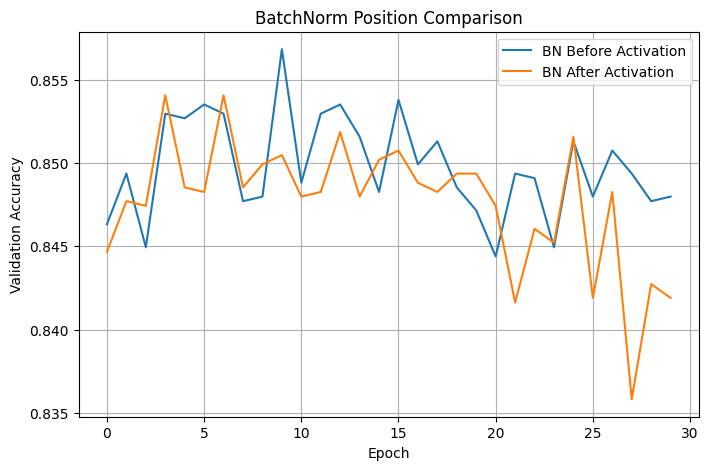

```python
plt.figure(figsize=(8,5))

plt.plot(history_bn_before.history["val_accuracy"], label="BN Before Activation")
plt.plot(history_bn_after.history["val_accuracy"], label="BN After Activation")

plt.title("BatchNorm Position Comparison")
plt.xlabel("Epoch")
plt.ylabel("Validation Accuracy")
plt.legend()
plt.grid(True)

plt.show()
```

- Two Batch Normalization orders were compared.
- The canonical order (**Dense → BatchNorm → ReLU**) is the original method proposed in the Batch Normalization paper.

## 6.5 Inspect Learned Gamma and Beta

```python
# First BatchNorm Layer
bn_layer = model_bn.layers[1]

gamma, beta, moving_mean, moving_variance = bn_layer.get_weights()

print("Gamma Shape:", gamma.shape)
print("Beta Shape :", beta.shape)
```

```
Gamma Shape: (128,)
Beta Shape : (128,)
```

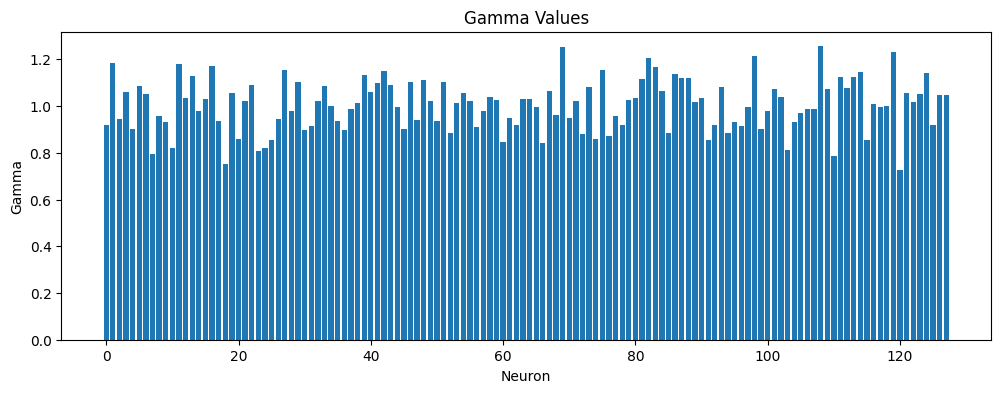

```python
# Gamma Plot
plt.figure(figsize=(12,4))

plt.bar(range(len(gamma)), gamma)

plt.title("Gamma Values")
plt.xlabel("Neuron")
plt.ylabel("Gamma")

plt.show()
```

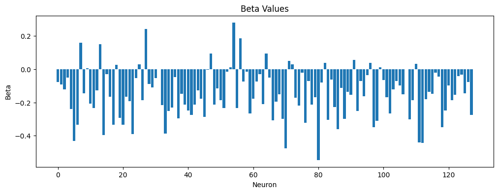

```python
# Beta Plot
plt.figure(figsize=(12,4))

plt.bar(range(len(beta)), beta)

plt.title("Beta Values")
plt.xlabel("Neuron")
plt.ylabel("Beta")

plt.show()
```

- The **Gamma (γ)** values show how much each feature is scaled after normalization.
- The **Beta (β)** values show the learned shift applied after normalization.
- Neurons with **Gamma values close to zero** contribute less to the final prediction.
- Neurons with **larger Gamma values** have a stronger influence on the model's output and represent more important learned features.

# Task 7: Optimizers — Convergence & Final Comparison

## 7.1 Build 5 Models with Different Optimisers

```python
from tensorflow.keras.optimizers import SGD, RMSprop, Adam

model_sgd = build_ann(
    input_dim=X_train.shape[1],
    activation="relu",
    initializer="he_normal",
    use_batch_norm=True,
    loss="binary_crossentropy",
    optimizer="sgd"
)

history_sgd = model_sgd.fit(
    X_train, y_train,
    epochs=50,
    batch_size=64,
    validation_split=0.1,
    verbose=1
)
```

```
509/509 ━━━━━━━━━━━━━━━━━━━━ 3s 4ms/step - accuracy: 0.8007 - loss: 0.4230 - val_accuracy: 0.8389 - val_loss: 0.3610
509/509 ━━━━━━━━━━━━━━━━━━━━ 2s 3ms/step - accuracy: 0.8404 - loss: 0.3458 - val_accuracy: 0.8458 - val_loss: 0.3434
509/509 ━━━━━━━━━━━━━━━━━━━━ 2s 3ms/step - accuracy: 0.8441 - loss: 0.3352 - val_accuracy: 0.8449 - val_loss: 0.3396
509/509 ━━━━━━━━━━━━━━━━━━━━ 2s 5ms/step - accuracy: 0.8455 - loss: 0.3313 - val_accuracy: 0.8472 - val_loss: 0.3357
509/509 ━━━━━━━━━━━━━━━━━━━━ 3s 4ms/step - accuracy: 0.8472 - loss: 0.3277 - val_accuracy: 0.8483 - val_loss: 0.3352
509/509 ━━━━━━━━━━━━━━━━━━━━ 2s 3ms/step - accuracy: 0.8481 - loss: 0.3244 - val_accuracy: 0.8455 - val_loss: 0.3316
509/509 ━━━━━━━━━━━━━━━━━━━━ 2s 3ms/step - accuracy: 0.8500 - loss: 0.3239 - val_accuracy: 0.8480 - val_loss: 0.3309
509/509 ━━━━━━━━━━━━━━━━━━━━ 2s 3ms/step - accuracy: 0.8490 - loss: 0.3217 - val_accuracy: 0.8483 - val_loss: 0.3298
509/509 ━━━━━━━━━━━━━━━━━━━━ 2s 3ms/step - accuracy: 0.8508 - loss: 0.3199 - val_accuracy: 0.8463 - val_loss: 0.3293
509/509 ━━━━━━━━━━━━━━━━━━━━ 2s 3ms/step - accuracy: 0.8516 - loss: 0.3179 - val_accuracy: 0.8483 - val_loss: 0.3286
509/509 ━━━━━━━━━━━━━━━━━━━━ 2s 5ms/step - accuracy: 0.8519 - loss: 0.3180 - val_accuracy: 0.8491 - val_loss: 0.3286
509/509 ━━━━━━━━━━━━━━━━━━━━ 2s 4ms/step - accuracy: 0.8521 - loss: 0.3165 - val_accuracy: 0.8480 - val_loss: 0.3286
509/509 ━━━━━━━━━━━━━━━━━━━━ 2s 3ms/step - accuracy: 0.8534 - loss: 0.3151 - val_accuracy: 0.8488 - val_loss: 0.3282
509/509 ━━━━━━━━━━━━━━━━━━━━ 2s 3ms/step - accuracy: 0.8545 - loss: 0.3144 - val_accuracy: 0.8502 - val_loss: 0.3268
509/509 ━━━━━━━━━━━━━━━━━━━━ 2s 3ms/step - accuracy: 0.8537 - loss: 0.3151 - val_accuracy: 0.8477 - val_loss: 0.3277
509/509 ━━━━━━━━━━━━━━━━━━━━ 2s 3ms/step - accuracy: 0.8544 - loss: 0.3142 - val_accuracy: 0.8491 - val_loss: 0.3260
509/509 ━━━━━━━━━━━━━━━━━━━━ 2s 4ms/step - accuracy: 0.8535 - loss: 0.3124 - val_accuracy: 0.8491 - val_loss: 0.3264
509/509 ━━━━━━━━━━━━━━━━━━━━ 2s 5ms/step - accuracy: 0.8540 - loss: 0.3115 - val_accuracy: 0.8513 - val_loss: 0.3262
509/509 ━━━━━━━━━━━━━━━━━━━━ 2s 4ms/step - accuracy: 0.8557 - loss: 0.3130 - val_accuracy: 0.8505 - val_loss: 0.3257
509/509 ━━━━━━━━━━━━━━━━━━━━ 2s 4ms/step - accuracy: 0.8560 - loss: 0.3124 - val_accuracy: 0.8499 - val_loss: 0.3256
509/509 ━━━━━━━━━━━━━━━━━━━━ 2s 3ms/step - accuracy: 0.8554 - loss: 0.3110 - val_accuracy: 0.8499 - val_loss: 0.3266
509/509 ━━━━━━━━━━━━━━━━━━━━ 2s 3ms/step - accuracy: 0.8560 - loss: 0.3106 - val_accuracy: 0.8491 - val_loss: 0.3277
509/509 ━━━━━━━━━━━━━━━━━━━━ 2s 3ms/step - accuracy: 0.8536 - loss: 0.3111 - val_accuracy: 0.8513 - val_loss: 0.3257
509/509 ━━━━━━━━━━━━━━━━━━━━ 2s 3ms/step - accuracy: 0.8556 - loss: 0.3089 - val_accuracy: 0.8513 - val_loss: 0.3266
509/509 ━━━━━━━━━━━━━━━━━━━━ 3s 5ms/step - accuracy: 0.8576 - loss: 0.3092 - val_accuracy: 0.8496 - val_loss: 0.3270
509/509 ━━━━━━━━━━━━━━━━━━━━ 2s 4ms/step - accuracy: 0.8566 - loss: 0.3105 - val_accuracy: 0.8494 - val_loss: 0.3263
509/509 ━━━━━━━━━━━━━━━━━━━━ 2s 4ms/step - accuracy: 0.8581 - loss: 0.3075 - val_accuracy: 0.8519 - val_loss: 0.3263
509/509 ━━━━━━━━━━━━━━━━━━━━ 2s 3ms/step - accuracy: 0.8564 - loss: 0.3075 - val_accuracy: 0.8502 - val_loss: 0.3258
509/509 ━━━━━━━━━━━━━━━━━━━━ 2s 3ms/step - accuracy: 0.8558 - loss: 0.3081 - val_accuracy: 0.8477 - val_loss: 0.3268
509/509 ━━━━━━━━━━━━━━━━━━━━ 2s 3ms/step - accuracy: 0.8578 - loss: 0.3062 - val_accuracy: 0.8507 - val_loss: 0.3258
509/509 ━━━━━━━━━━━━━━━━━━━━ 2s 4ms/step - accuracy: 0.8577 - loss: 0.3059 - val_accuracy: 0.8513 - val_loss: 0.3257
509/509 ━━━━━━━━━━━━━━━━━━━━ 3s 5ms/step - accuracy: 0.8573 - loss: 0.3069 - val_accuracy: 0.8516 - val_loss: 0.3272
509/509 ━━━━━━━━━━━━━━━━━━━━ 2s 3ms/step - accuracy: 0.8583 - loss: 0.3065 - val_accuracy: 0.8510 - val_loss: 0.3263
509/509 ━━━━━━━━━━━━━━━━━━━━ 3s 3ms/step - accuracy: 0.8576 - loss: 0.3054 - val_accuracy: 0.8499 - val_loss: 0.3257
509/509 ━━━━━━━━━━━━━━━━━━━━ 2s 3ms/step - accuracy: 0.8589 - loss: 0.3051 - val_accuracy: 0.8466 - val_loss: 0.3267
509/509 ━━━━━━━━━━━━━━━━━━━━ 2s 3ms/step - accuracy: 0.8582 - loss: 0.3058 - val_accuracy: 0.8516 - val_loss: 0.3253
509/509 ━━━━━━━━━━━━━━━━━━━━ 2s 3ms/step - accuracy: 0.8572 - loss: 0.3051 - val_accuracy: 0.8513 - val_loss: 0.3263
509/509 ━━━━━━━━━━━━━━━━━━━━ 3s 5ms/step - accuracy: 0.8588 - loss: 0.3025 - val_accuracy: 0.8507 - val_loss: 0.3268
509/509 ━━━━━━━━━━━━━━━━━━━━ 2s 4ms/step - accuracy: 0.8583 - loss: 0.3033 - val_accuracy: 0.8488 - val_loss: 0.3272
509/509 ━━━━━━━━━━━━━━━━━━━━ 2s 3ms/step - accuracy: 0.8590 - loss: 0.3018 - val_accuracy: 0.8496 - val_loss: 0.3275
509/509 ━━━━━━━━━━━━━━━━━━━━ 2s 3ms/step - accuracy: 0.8585 - loss: 0.3038 - val_accuracy: 0.8505 - val_loss: 0.3279
509/509 ━━━━━━━━━━━━━━━━━━━━ 2s 3ms/step - accuracy: 0.8587 - loss: 0.3026 - val_accuracy: 0.8485 - val_loss: 0.3268
509/509 ━━━━━━━━━━━━━━━━━━━━ 2s 3ms/step - accuracy: 0.8582 - loss: 0.3025 - val_accuracy: 0.8538 - val_loss: 0.3274
509/509 ━━━━━━━━━━━━━━━━━━━━ 2s 3ms/step - accuracy: 0.8614 - loss: 0.3006 - val_accuracy: 0.8505 - val_loss: 0.3277
509/509 ━━━━━━━━━━━━━━━━━━━━ 2s 4ms/step - accuracy: 0.8594 - loss: 0.3027 - val_accuracy: 0.8505 - val_loss: 0.3264
509/509 ━━━━━━━━━━━━━━━━━━━━ 2s 5ms/step - accuracy: 0.8613 - loss: 0.2996 - val_accuracy: 0.8499 - val_loss: 0.3274
509/509 ━━━━━━━━━━━━━━━━━━━━ 2s 3ms/step - accuracy: 0.8621 - loss: 0.3010 - val_accuracy: 0.8494 - val_loss: 0.3273
509/509 ━━━━━━━━━━━━━━━━━━━━ 2s 3ms/step - accuracy: 0.8602 - loss: 0.3009 - val_accuracy: 0.8502 - val_loss: 0.3284
509/509 ━━━━━━━━━━━━━━━━━━━━ 2s 3ms/step - accuracy: 0.8624 - loss: 0.2984 - val_accuracy: 0.8513 - val_loss: 0.3267
509/509 ━━━━━━━━━━━━━━━━━━━━ 2s 3ms/step - accuracy: 0.8603 - loss: 0.2993 - val_accuracy: 0.8505 - val_loss: 0.3281
```

```python
# SGD + Momentum
model_momentum = build_ann(
    input_dim=X_train.shape[1],
    activation="relu",
    initializer="he_normal",
    use_batch_norm=True,
    loss="binary_crossentropy",
    optimizer=SGD(learning_rate=0.01, momentum=0.9)
)

history_momentum = model_momentum.fit(
    X_train, y_train,
    epochs=50,
    batch_size=64,
    validation_split=0.1,
    verbose=1
)
```

```
509/509 ━━━━━━━━━━━━━━━━━━━━ 3s 4ms/step - accuracy: 0.8353 - loss: 0.3501 - val_accuracy: 0.8491 - val_loss: 0.3291
509/509 ━━━━━━━━━━━━━━━━━━━━ 3s 5ms/step - accuracy: 0.8491 - loss: 0.3234 - val_accuracy: 0.8480 - val_loss: 0.3264
509/509 ━━━━━━━━━━━━━━━━━━━━ 2s 4ms/step - accuracy: 0.8519 - loss: 0.3177 - val_accuracy: 0.8510 - val_loss: 0.3212
509/509 ━━━━━━━━━━━━━━━━━━━━ 2s 4ms/step - accuracy: 0.8523 - loss: 0.3157 - val_accuracy: 0.8521 - val_loss: 0.3266
509/509 ━━━━━━━━━━━━━━━━━━━━ 2s 3ms/step - accuracy: 0.8544 - loss: 0.3118 - val_accuracy: 0.8488 - val_loss: 0.3236
509/509 ━━━━━━━━━━━━━━━━━━━━ 2s 3ms/step - accuracy: 0.8533 - loss: 0.3102 - val_accuracy: 0.8507 - val_loss: 0.3203
509/509 ━━━━━━━━━━━━━━━━━━━━ 2s 3ms/step - accuracy: 0.8557 - loss: 0.3088 - val_accuracy: 0.8516 - val_loss: 0.3227
509/509 ━━━━━━━━━━━━━━━━━━━━ 2s 3ms/step - accuracy: 0.8561 - loss: 0.3079 - val_accuracy: 0.8507 - val_loss: 0.3217
509/509 ━━━━━━━━━━━━━━━━━━━━ 3s 5ms/step - accuracy: 0.8566 - loss: 0.3063 - val_accuracy: 0.8510 - val_loss: 0.3273
509/509 ━━━━━━━━━━━━━━━━━━━━ 2s 4ms/step - accuracy: 0.8560 - loss: 0.3056 - val_accuracy: 0.8438 - val_loss: 0.3247
509/509 ━━━━━━━━━━━━━━━━━━━━ 2s 3ms/step - accuracy: 0.8576 - loss: 0.3046 - val_accuracy: 0.8535 - val_loss: 0.3234
509/509 ━━━━━━━━━━━━━━━━━━━━ 2s 3ms/step - accuracy: 0.8575 - loss: 0.3024 - val_accuracy: 0.8463 - val_loss: 0.3237
509/509 ━━━━━━━━━━━━━━━━━━━━ 2s 3ms/step - accuracy: 0.8570 - loss: 0.3021 - val_accuracy: 0.8505 - val_loss: 0.3275
509/509 ━━━━━━━━━━━━━━━━━━━━ 3s 4ms/step - accuracy: 0.8583 - loss: 0.3006 - val_accuracy: 0.8499 - val_loss: 0.3206
509/509 ━━━━━━━━━━━━━━━━━━━━ 2s 4ms/step - accuracy: 0.8607 - loss: 0.2994 - val_accuracy: 0.8516 - val_loss: 0.3236
509/509 ━━━━━━━━━━━━━━━━━━━━ 3s 6ms/step - accuracy: 0.8599 - loss: 0.2985 - val_accuracy: 0.8494 - val_loss: 0.3237
509/509 ━━━━━━━━━━━━━━━━━━━━ 2s 3ms/step - accuracy: 0.8613 - loss: 0.2968 - val_accuracy: 0.8463 - val_loss: 0.3297
509/509 ━━━━━━━━━━━━━━━━━━━━ 2s 3ms/step - accuracy: 0.8593 - loss: 0.2971 - val_accuracy: 0.8460 - val_loss: 0.3280
509/509 ━━━━━━━━━━━━━━━━━━━━ 2s 3ms/step - accuracy: 0.8621 - loss: 0.2930 - val_accuracy: 0.8483 - val_loss: 0.3287
509/509 ━━━━━━━━━━━━━━━━━━━━ 2s 3ms/step - accuracy: 0.8630 - loss: 0.2958 - val_accuracy: 0.8386 - val_loss: 0.3313
509/509 ━━━━━━━━━━━━━━━━━━━━ 2s 3ms/step - accuracy: 0.8630 - loss: 0.2923 - val_accuracy: 0.8449 - val_loss: 0.3268
509/509 ━━━━━━━━━━━━━━━━━━━━ 2s 4ms/step - accuracy: 0.8627 - loss: 0.2914 - val_accuracy: 0.8375 - val_loss: 0.3336
509/509 ━━━━━━━━━━━━━━━━━━━━ 3s 5ms/step - accuracy: 0.8634 - loss: 0.2916 - val_accuracy: 0.8419 - val_loss: 0.3345
509/509 ━━━━━━━━━━━━━━━━━━━━ 2s 3ms/step - accuracy: 0.8650 - loss: 0.2900 - val_accuracy: 0.8499 - val_loss: 0.3290
509/509 ━━━━━━━━━━━━━━━━━━━━ 2s 3ms/step - accuracy: 0.8643 - loss: 0.2898 - val_accuracy: 0.8460 - val_loss: 0.3265
509/509 ━━━━━━━━━━━━━━━━━━━━ 2s 3ms/step - accuracy: 0.8656 - loss: 0.2876 - val_accuracy: 0.8438 - val_loss: 0.3309
509/509 ━━━━━━━━━━━━━━━━━━━━ 2s 3ms/step - accuracy: 0.8653 - loss: 0.2865 - val_accuracy: 0.8438 - val_loss: 0.3283
509/509 ━━━━━━━━━━━━━━━━━━━━ 2s 3ms/step - accuracy: 0.8673 - loss: 0.2859 - val_accuracy: 0.8507 - val_loss: 0.3328
509/509 ━━━━━━━━━━━━━━━━━━━━ 3s 5ms/step - accuracy: 0.8657 - loss: 0.2848 - val_accuracy: 0.8460 - val_loss: 0.3303
509/509 ━━━━━━━━━━━━━━━━━━━━ 2s 3ms/step - accuracy: 0.8666 - loss: 0.2845 - val_accuracy: 0.8449 - val_loss: 0.3284
509/509 ━━━━━━━━━━━━━━━━━━━━ 2s 3ms/step - accuracy: 0.8664 - loss: 0.2856 - val_accuracy: 0.8422 - val_loss: 0.3363
509/509 ━━━━━━━━━━━━━━━━━━━━ 3s 4ms/step - accuracy: 0.8666 - loss: 0.2820 - val_accuracy: 0.8438 - val_loss: 0.3341
509/509 ━━━━━━━━━━━━━━━━━━━━ 2s 3ms/step - accuracy: 0.8686 - loss: 0.2825 - val_accuracy: 0.8505 - val_loss: 0.3340
509/509 ━━━━━━━━━━━━━━━━━━━━ 2s 3ms/step - accuracy: 0.8660 - loss: 0.2827 - val_accuracy: 0.8438 - val_loss: 0.3324
509/509 ━━━━━━━━━━━━━━━━━━━━ 2s 5ms/step - accuracy: 0.8673 - loss: 0.2833 - val_accuracy: 0.8472 - val_loss: 0.3321
509/509 ━━━━━━━━━━━━━━━━━━━━ 3s 5ms/step - accuracy: 0.8689 - loss: 0.2801 - val_accuracy: 0.8441 - val_loss: 0.3356
509/509 ━━━━━━━━━━━━━━━━━━━━ 2s 3ms/step - accuracy: 0.8685 - loss: 0.2804 - val_accuracy: 0.8425 - val_loss: 0.3336
509/509 ━━━━━━━━━━━━━━━━━━━━ 2s 3ms/step - accuracy: 0.8680 - loss: 0.2797 - val_accuracy: 0.8441 - val_loss: 0.3369
509/509 ━━━━━━━━━━━━━━━━━━━━ 2s 3ms/step - accuracy: 0.8683 - loss: 0.2775 - val_accuracy: 0.8416 - val_loss: 0.3379
509/509 ━━━━━━━━━━━━━━━━━━━━ 2s 3ms/step - accuracy: 0.8701 - loss: 0.2787 - val_accuracy: 0.8472 - val_loss: 0.3352
509/509 ━━━━━━━━━━━━━━━━━━━━ 2s 3ms/step - accuracy: 0.8708 - loss: 0.2762 - val_accuracy: 0.8483 - val_loss: 0.3412
509/509 ━━━━━━━━━━━━━━━━━━━━ 2s 4ms/step - accuracy: 0.8695 - loss: 0.2757 - val_accuracy: 0.8452 - val_loss: 0.3370
509/509 ━━━━━━━━━━━━━━━━━━━━ 3s 4ms/step - accuracy: 0.8705 - loss: 0.2742 - val_accuracy: 0.8455 - val_loss: 0.3371
509/509 ━━━━━━━━━━━━━━━━━━━━ 2s 3ms/step - accuracy: 0.8715 - loss: 0.2745 - val_accuracy: 0.8400 - val_loss: 0.3405
509/509 ━━━━━━━━━━━━━━━━━━━━ 2s 3ms/step - accuracy: 0.8708 - loss: 0.2733 - val_accuracy: 0.8485 - val_loss: 0.3379
509/509 ━━━━━━━━━━━━━━━━━━━━ 2s 3ms/step - accuracy: 0.8703 - loss: 0.2753 - val_accuracy: 0.8494 - val_loss: 0.3366
509/509 ━━━━━━━━━━━━━━━━━━━━ 2s 3ms/step - accuracy: 0.8714 - loss: 0.2721 - val_accuracy: 0.8444 - val_loss: 0.3363
509/509 ━━━━━━━━━━━━━━━━━━━━ 2s 3ms/step - accuracy: 0.8723 - loss: 0.2727 - val_accuracy: 0.8389 - val_loss: 0.3383
509/509 ━━━━━━━━━━━━━━━━━━━━ 2s 4ms/step - accuracy: 0.8731 - loss: 0.2727 - val_accuracy: 0.8458 - val_loss: 0.3414
509/509 ━━━━━━━━━━━━━━━━━━━━ 3s 5ms/step - accuracy: 0.8728 - loss: 0.2707 - val_accuracy: 0.8438 - val_loss: 0.3392
```

```python
# RMSprop
model_rmsprop = build_ann(
    input_dim=X_train.shape[1],
    activation="relu",
    initializer="he_normal",
    use_batch_norm=True,
    loss="binary_crossentropy",
    optimizer="rmsprop"
)

history_rmsprop = model_rmsprop.fit(
    X_train, y_train,
    epochs=50,
    batch_size=64,
    validation_split=0.1,
    verbose=1
)
```

```
509/509 ━━━━━━━━━━━━━━━━━━━━ 3s 4ms/step - accuracy: 0.8348 - loss: 0.3619 - val_accuracy: 0.8458 - val_loss: 0.3292
509/509 ━━━━━━━━━━━━━━━━━━━━ 2s 3ms/step - accuracy: 0.8496 - loss: 0.3216 - val_accuracy: 0.8485 - val_loss: 0.3296
509/509 ━━━━━━━━━━━━━━━━━━━━ 2s 3ms/step - accuracy: 0.8530 - loss: 0.3167 - val_accuracy: 0.8496 - val_loss: 0.3287
509/509 ━━━━━━━━━━━━━━━━━━━━ 3s 5ms/step - accuracy: 0.8552 - loss: 0.3125 - val_accuracy: 0.8513 - val_loss: 0.3236
509/509 ━━━━━━━━━━━━━━━━━━━━ 2s 4ms/step - accuracy: 0.8569 - loss: 0.3110 - val_accuracy: 0.8560 - val_loss: 0.3278
509/509 ━━━━━━━━━━━━━━━━━━━━ 2s 3ms/step - accuracy: 0.8562 - loss: 0.3078 - val_accuracy: 0.8552 - val_loss: 0.3248
509/509 ━━━━━━━━━━━━━━━━━━━━ 2s 3ms/step - accuracy: 0.8572 - loss: 0.3070 - val_accuracy: 0.8510 - val_loss: 0.3262
509/509 ━━━━━━━━━━━━━━━━━━━━ 2s 3ms/step - accuracy: 0.8591 - loss: 0.3047 - val_accuracy: 0.8452 - val_loss: 0.3316
509/509 ━━━━━━━━━━━━━━━━━━━━ 2s 3ms/step - accuracy: 0.8588 - loss: 0.3035 - val_accuracy: 0.8535 - val_loss: 0.3250
509/509 ━━━━━━━━━━━━━━━━━━━━ 2s 3ms/step - accuracy: 0.8605 - loss: 0.3010 - val_accuracy: 0.8488 - val_loss: 0.3266
509/509 ━━━━━━━━━━━━━━━━━━━━ 3s 5ms/step - accuracy: 0.8623 - loss: 0.2990 - val_accuracy: 0.8519 - val_loss: 0.3329
509/509 ━━━━━━━━━━━━━━━━━━━━ 2s 4ms/step - accuracy: 0.8628 - loss: 0.2981 - val_accuracy: 0.8568 - val_loss: 0.3261
509/509 ━━━━━━━━━━━━━━━━━━━━ 2s 3ms/step - accuracy: 0.8637 - loss: 0.2970 - val_accuracy: 0.8541 - val_loss: 0.3293
509/509 ━━━━━━━━━━━━━━━━━━━━ 2s 3ms/step - accuracy: 0.8638 - loss: 0.2942 - val_accuracy: 0.8496 - val_loss: 0.3305
509/509 ━━━━━━━━━━━━━━━━━━━━ 2s 3ms/step - accuracy: 0.8643 - loss: 0.2944 - val_accuracy: 0.8535 - val_loss: 0.3273
509/509 ━━━━━━━━━━━━━━━━━━━━ 2s 3ms/step - accuracy: 0.8651 - loss: 0.2920 - val_accuracy: 0.8494 - val_loss: 0.3281
509/509 ━━━━━━━━━━━━━━━━━━━━ 2s 4ms/step - accuracy: 0.8663 - loss: 0.2918 - val_accuracy: 0.8491 - val_loss: 0.3257
509/509 ━━━━━━━━━━━━━━━━━━━━ 3s 5ms/step - accuracy: 0.8643 - loss: 0.2917 - val_accuracy: 0.8524 - val_loss: 0.3330
509/509 ━━━━━━━━━━━━━━━━━━━━ 2s 4ms/step - accuracy: 0.8667 - loss: 0.2898 - val_accuracy: 0.8499 - val_loss: 0.3302
509/509 ━━━━━━━━━━━━━━━━━━━━ 2s 3ms/step - accuracy: 0.8664 - loss: 0.2872 - val_accuracy: 0.8513 - val_loss: 0.3344
509/509 ━━━━━━━━━━━━━━━━━━━━ 2s 4ms/step - accuracy: 0.8669 - loss: 0.2878 - val_accuracy: 0.8505 - val_loss: 0.3311
509/509 ━━━━━━━━━━━━━━━━━━━━ 2s 3ms/step - accuracy: 0.8663 - loss: 0.2866 - val_accuracy: 0.8499 - val_loss: 0.3311
509/509 ━━━━━━━━━━━━━━━━━━━━ 2s 4ms/step - accuracy: 0.8698 - loss: 0.2850 - val_accuracy: 0.8513 - val_loss: 0.3317
509/509 ━━━━━━━━━━━━━━━━━━━━ 2s 4ms/step - accuracy: 0.8685 - loss: 0.2849 - val_accuracy: 0.8483 - val_loss: 0.3316
509/509 ━━━━━━━━━━━━━━━━━━━━ 3s 5ms/step - accuracy: 0.8677 - loss: 0.2845 - val_accuracy: 0.8477 - val_loss: 0.3301
509/509 ━━━━━━━━━━━━━━━━━━━━ 2s 4ms/step - accuracy: 0.8678 - loss: 0.2834 - val_accuracy: 0.8519 - val_loss: 0.3367
509/509 ━━━━━━━━━━━━━━━━━━━━ 2s 3ms/step - accuracy: 0.8697 - loss: 0.2814 - val_accuracy: 0.8458 - val_loss: 0.3406
509/509 ━━━━━━━━━━━━━━━━━━━━ 2s 3ms/step - accuracy: 0.8701 - loss: 0.2805 - val_accuracy: 0.8549 - val_loss: 0.3324
509/509 ━━━━━━━━━━━━━━━━━━━━ 3s 4ms/step - accuracy: 0.8705 - loss: 0.2804 - val_accuracy: 0.8494 - val_loss: 0.3352
509/509 ━━━━━━━━━━━━━━━━━━━━ 2s 3ms/step - accuracy: 0.8699 - loss: 0.2803 - val_accuracy: 0.8510 - val_loss: 0.3332
509/509 ━━━━━━━━━━━━━━━━━━━━ 3s 6ms/step - accuracy: 0.8703 - loss: 0.2782 - val_accuracy: 0.8516 - val_loss: 0.3316
509/509 ━━━━━━━━━━━━━━━━━━━━ 2s 4ms/step - accuracy: 0.8716 - loss: 0.2788 - val_accuracy: 0.8516 - val_loss: 0.3347
509/509 ━━━━━━━━━━━━━━━━━━━━ 2s 3ms/step - accuracy: 0.8712 - loss: 0.2776 - val_accuracy: 0.8513 - val_loss: 0.3327
509/509 ━━━━━━━━━━━━━━━━━━━━ 2s 3ms/step - accuracy: 0.8716 - loss: 0.2775 - val_accuracy: 0.8510 - val_loss: 0.3350
509/509 ━━━━━━━━━━━━━━━━━━━━ 2s 3ms/step - accuracy: 0.8726 - loss: 0.2769 - val_accuracy: 0.8469 - val_loss: 0.3313
509/509 ━━━━━━━━━━━━━━━━━━━━ 2s 3ms/step - accuracy: 0.8705 - loss: 0.2761 - val_accuracy: 0.8466 - val_loss: 0.3394
509/509 ━━━━━━━━━━━━━━━━━━━━ 2s 3ms/step - accuracy: 0.8724 - loss: 0.2745 - val_accuracy: 0.8491 - val_loss: 0.3378
509/509 ━━━━━━━━━━━━━━━━━━━━ 2s 5ms/step - accuracy: 0.8706 - loss: 0.2766 - val_accuracy: 0.8507 - val_loss: 0.3392
509/509 ━━━━━━━━━━━━━━━━━━━━ 2s 4ms/step - accuracy: 0.8727 - loss: 0.2732 - val_accuracy: 0.8463 - val_loss: 0.3395
509/509 ━━━━━━━━━━━━━━━━━━━━ 2s 3ms/step - accuracy: 0.8718 - loss: 0.2735 - val_accuracy: 0.8472 - val_loss: 0.3434
509/509 ━━━━━━━━━━━━━━━━━━━━ 2s 3ms/step - accuracy: 0.8751 - loss: 0.2718 - val_accuracy: 0.8483 - val_loss: 0.3469
509/509 ━━━━━━━━━━━━━━━━━━━━ 2s 3ms/step - accuracy: 0.8717 - loss: 0.2737 - val_accuracy: 0.8549 - val_loss: 0.3371
509/509 ━━━━━━━━━━━━━━━━━━━━ 2s 3ms/step - accuracy: 0.8739 - loss: 0.2711 - val_accuracy: 0.8491 - val_loss: 0.3373
509/509 ━━━━━━━━━━━━━━━━━━━━ 2s 3ms/step - accuracy: 0.8760 - loss: 0.2700 - val_accuracy: 0.8474 - val_loss: 0.3348
509/509 ━━━━━━━━━━━━━━━━━━━━ 2s 4ms/step - accuracy: 0.8732 - loss: 0.2704 - val_accuracy: 0.8491 - val_loss: 0.3442
509/509 ━━━━━━━━━━━━━━━━━━━━ 3s 5ms/step - accuracy: 0.8755 - loss: 0.2695 - val_accuracy: 0.8499 - val_loss: 0.3453
509/509 ━━━━━━━━━━━━━━━━━━━━ 2s 4ms/step - accuracy: 0.8748 - loss: 0.2705 - val_accuracy: 0.8532 - val_loss: 0.3407
509/509 ━━━━━━━━━━━━━━━━━━━━ 2s 3ms/step - accuracy: 0.8747 - loss: 0.2681 - val_accuracy: 0.8483 - val_loss: 0.3490
509/509 ━━━━━━━━━━━━━━━━━━━━ 2s 3ms/step - accuracy: 0.8755 - loss: 0.2677 - val_accuracy: 0.8494 - val_loss: 0.3414
509/509 ━━━━━━━━━━━━━━━━━━━━ 3s 4ms/step - accuracy: 0.8750 - loss: 0.2676 - val_accuracy: 0.8519 - val_loss: 0.3414
```

```python
# Adam (Default)
model_adam = build_ann(
    input_dim=X_train.shape[1],
    activation="relu",
    initializer="he_normal",
    use_batch_norm=True,
    loss="binary_crossentropy",
    optimizer="adam"
)

history_adam = model_adam.fit(
    X_train, y_train,
    epochs=50,
    batch_size=64,
    validation_split=0.1,
    verbose=1
)
```

```
509/509 ━━━━━━━━━━━━━━━━━━━━ 5s 5ms/step - accuracy: 0.8295 - loss: 0.3747 - val_accuracy: 0.8416 - val_loss: 0.3388
509/509 ━━━━━━━━━━━━━━━━━━━━ 4s 4ms/step - accuracy: 0.8497 - loss: 0.3229 - val_accuracy: 0.8485 - val_loss: 0.3245
509/509 ━━━━━━━━━━━━━━━━━━━━ 2s 4ms/step - accuracy: 0.8528 - loss: 0.3149 - val_accuracy: 0.8505 - val_loss: 0.3242
509/509 ━━━━━━━━━━━━━━━━━━━━ 2s 4ms/step - accuracy: 0.8546 - loss: 0.3121 - val_accuracy: 0.8480 - val_loss: 0.3236
509/509 ━━━━━━━━━━━━━━━━━━━━ 2s 5ms/step - accuracy: 0.8573 - loss: 0.3063 - val_accuracy: 0.8416 - val_loss: 0.3368
509/509 ━━━━━━━━━━━━━━━━━━━━ 3s 5ms/step - accuracy: 0.8563 - loss: 0.3055 - val_accuracy: 0.8472 - val_loss: 0.3363
509/509 ━━━━━━━━━━━━━━━━━━━━ 2s 4ms/step - accuracy: 0.8607 - loss: 0.3015 - val_accuracy: 0.8474 - val_loss: 0.3213
509/509 ━━━━━━━━━━━━━━━━━━━━ 2s 4ms/step - accuracy: 0.8597 - loss: 0.2998 - val_accuracy: 0.8543 - val_loss: 0.3222
509/509 ━━━━━━━━━━━━━━━━━━━━ 2s 3ms/step - accuracy: 0.8621 - loss: 0.2960 - val_accuracy: 0.8552 - val_loss: 0.3193
509/509 ━━━━━━━━━━━━━━━━━━━━ 2s 3ms/step - accuracy: 0.8638 - loss: 0.2940 - val_accuracy: 0.8505 - val_loss: 0.3244
509/509 ━━━━━━━━━━━━━━━━━━━━ 2s 3ms/step - accuracy: 0.8626 - loss: 0.2941 - val_accuracy: 0.8485 - val_loss: 0.3266
509/509 ━━━━━━━━━━━━━━━━━━━━ 3s 5ms/step - accuracy: 0.8648 - loss: 0.2905 - val_accuracy: 0.8543 - val_loss: 0.3229
509/509 ━━━━━━━━━━━━━━━━━━━━ 2s 5ms/step - accuracy: 0.8655 - loss: 0.2887 - val_accuracy: 0.8505 - val_loss: 0.3229
509/509 ━━━━━━━━━━━━━━━━━━━━ 2s 3ms/step - accuracy: 0.8656 - loss: 0.2869 - val_accuracy: 0.8502 - val_loss: 0.3284
509/509 ━━━━━━━━━━━━━━━━━━━━ 2s 4ms/step - accuracy: 0.8677 - loss: 0.2833 - val_accuracy: 0.8477 - val_loss: 0.3274
509/509 ━━━━━━━━━━━━━━━━━━━━ 2s 3ms/step - accuracy: 0.8670 - loss: 0.2843 - val_accuracy: 0.8494 - val_loss: 0.3301
509/509 ━━━━━━━━━━━━━━━━━━━━ 2s 4ms/step - accuracy: 0.8697 - loss: 0.2816 - val_accuracy: 0.8485 - val_loss: 0.3307
509/509 ━━━━━━━━━━━━━━━━━━━━ 2s 4ms/step - accuracy: 0.8688 - loss: 0.2806 - val_accuracy: 0.8554 - val_loss: 0.3283
509/509 ━━━━━━━━━━━━━━━━━━━━ 3s 6ms/step - accuracy: 0.8676 - loss: 0.2794 - val_accuracy: 0.8485 - val_loss: 0.3327
509/509 ━━━━━━━━━━━━━━━━━━━━ 2s 4ms/step - accuracy: 0.8703 - loss: 0.2767 - val_accuracy: 0.8502 - val_loss: 0.3327
509/509 ━━━━━━━━━━━━━━━━━━━━ 2s 4ms/step - accuracy: 0.8702 - loss: 0.2778 - val_accuracy: 0.8460 - val_loss: 0.3352
509/509 ━━━━━━━━━━━━━━━━━━━━ 2s 4ms/step - accuracy: 0.8695 - loss: 0.2752 - val_accuracy: 0.8538 - val_loss: 0.3316
509/509 ━━━━━━━━━━━━━━━━━━━━ 2s 4ms/step - accuracy: 0.8714 - loss: 0.2733 - val_accuracy: 0.8535 - val_loss: 0.3350
509/509 ━━━━━━━━━━━━━━━━━━━━ 2s 4ms/step - accuracy: 0.8722 - loss: 0.2722 - val_accuracy: 0.8477 - val_loss: 0.3394
509/509 ━━━━━━━━━━━━━━━━━━━━ 3s 5ms/step - accuracy: 0.8717 - loss: 0.2704 - val_accuracy: 0.8427 - val_loss: 0.3409
509/509 ━━━━━━━━━━━━━━━━━━━━ 3s 5ms/step - accuracy: 0.8741 - loss: 0.2696 - val_accuracy: 0.8491 - val_loss: 0.3325
509/509 ━━━━━━━━━━━━━━━━━━━━ 2s 4ms/step - accuracy: 0.8746 - loss: 0.2690 - val_accuracy: 0.8496 - val_loss: 0.3422
509/509 ━━━━━━━━━━━━━━━━━━━━ 2s 4ms/step - accuracy: 0.8733 - loss: 0.2687 - val_accuracy: 0.8488 - val_loss: 0.3434
509/509 ━━━━━━━━━━━━━━━━━━━━ 2s 4ms/step - accuracy: 0.8746 - loss: 0.2665 - val_accuracy: 0.8436 - val_loss: 0.3427
509/509 ━━━━━━━━━━━━━━━━━━━━ 2s 3ms/step - accuracy: 0.8763 - loss: 0.2649 - val_accuracy: 0.8397 - val_loss: 0.3493
509/509 ━━━━━━━━━━━━━━━━━━━━ 2s 4ms/step - accuracy: 0.8749 - loss: 0.2632 - val_accuracy: 0.8438 - val_loss: 0.3455
509/509 ━━━━━━━━━━━━━━━━━━━━ 3s 6ms/step - accuracy: 0.8757 - loss: 0.2629 - val_accuracy: 0.8458 - val_loss: 0.3498
509/509 ━━━━━━━━━━━━━━━━━━━━ 2s 4ms/step - accuracy: 0.8748 - loss: 0.2638 - val_accuracy: 0.8447 - val_loss: 0.3492
509/509 ━━━━━━━━━━━━━━━━━━━━ 2s 4ms/step - accuracy: 0.8756 - loss: 0.2623 - val_accuracy: 0.8463 - val_loss: 0.3495
509/509 ━━━━━━━━━━━━━━━━━━━━ 2s 4ms/step - accuracy: 0.8761 - loss: 0.2607 - val_accuracy: 0.8416 - val_loss: 0.3510
509/509 ━━━━━━━━━━━━━━━━━━━━ 2s 4ms/step - accuracy: 0.8774 - loss: 0.2597 - val_accuracy: 0.8425 - val_loss: 0.3521
509/509 ━━━━━━━━━━━━━━━━━━━━ 2s 4ms/step - accuracy: 0.8785 - loss: 0.2579 - val_accuracy: 0.8436 - val_loss: 0.3566
509/509 ━━━━━━━━━━━━━━━━━━━━ 3s 6ms/step - accuracy: 0.8757 - loss: 0.2589 - val_accuracy: 0.8469 - val_loss: 0.3540
509/509 ━━━━━━━━━━━━━━━━━━━━ 4s 4ms/step - accuracy: 0.8779 - loss: 0.2570 - val_accuracy: 0.8425 - val_loss: 0.3663
509/509 ━━━━━━━━━━━━━━━━━━━━ 2s 3ms/step - accuracy: 0.8779 - loss: 0.2578 - val_accuracy: 0.8447 - val_loss: 0.3580
509/509 ━━━━━━━━━━━━━━━━━━━━ 2s 4ms/step - accuracy: 0.8792 - loss: 0.2549 - val_accuracy: 0.8496 - val_loss: 0.3639
509/509 ━━━━━━━━━━━━━━━━━━━━ 2s 3ms/step - accuracy: 0.8801 - loss: 0.2541 - val_accuracy: 0.8378 - val_loss: 0.3703
509/509 ━━━━━━━━━━━━━━━━━━━━ 2s 4ms/step - accuracy: 0.8788 - loss: 0.2544 - val_accuracy: 0.8452 - val_loss: 0.3594
509/509 ━━━━━━━━━━━━━━━━━━━━ 3s 5ms/step - accuracy: 0.8792 - loss: 0.2551 - val_accuracy: 0.8427 - val_loss: 0.3604
509/509 ━━━━━━━━━━━━━━━━━━━━ 2s 4ms/step - accuracy: 0.8799 - loss: 0.2531 - val_accuracy: 0.8378 - val_loss: 0.3719
509/509 ━━━━━━━━━━━━━━━━━━━━ 2s 3ms/step - accuracy: 0.8810 - loss: 0.2522 - val_accuracy: 0.8472 - val_loss: 0.3617
509/509 ━━━━━━━━━━━━━━━━━━━━ 2s 3ms/step - accuracy: 0.8826 - loss: 0.2511 - val_accuracy: 0.8402 - val_loss: 0.3738
509/509 ━━━━━━━━━━━━━━━━━━━━ 2s 3ms/step - accuracy: 0.8814 - loss: 0.2519 - val_accuracy: 0.8463 - val_loss: 0.3642
509/509 ━━━━━━━━━━━━━━━━━━━━ 2s 3ms/step - accuracy: 0.8821 - loss: 0.2501 - val_accuracy: 0.8394 - val_loss: 0.3766
509/509 ━━━━━━━━━━━━━━━━━━━━ 2s 5ms/step - accuracy: 0.8799 - loss: 0.2506 - val_accuracy: 0.8452 - val_loss: 0.3741
```

```python
# Adam (Explicit Parameters)
model_adam_explicit = build_ann(
    input_dim=X_train.shape[1],
    activation="relu",
    initializer="he_normal",
    use_batch_norm=True,
    loss="binary_crossentropy",
    optimizer=Adam(
        learning_rate=0.001,
        beta_1=0.9,
        beta_2=0.999
    )
)

history_adam_explicit = model_adam_explicit.fit(
    X_train, y_train,
    epochs=50,
    batch_size=64,
    validation_split=0.1,
    verbose=1
)
```

```
509/509 ━━━━━━━━━━━━━━━━━━━━ 5s 4ms/step - accuracy: 0.8303 - loss: 0.3709 - val_accuracy: 0.8507 - val_loss: 0.3260
509/509 ━━━━━━━━━━━━━━━━━━━━ 2s 3ms/step - accuracy: 0.8487 - loss: 0.3228 - val_accuracy: 0.8541 - val_loss: 0.3232
509/509 ━━━━━━━━━━━━━━━━━━━━ 2s 3ms/step - accuracy: 0.8526 - loss: 0.3156 - val_accuracy: 0.8543 - val_loss: 0.3235
509/509 ━━━━━━━━━━━━━━━━━━━━ 2s 4ms/step - accuracy: 0.8540 - loss: 0.3099 - val_accuracy: 0.8552 - val_loss: 0.3213
509/509 ━━━━━━━━━━━━━━━━━━━━ 2s 5ms/step - accuracy: 0.8566 - loss: 0.3071 - val_accuracy: 0.8571 - val_loss: 0.3227
509/509 ━━━━━━━━━━━━━━━━━━━━ 3s 5ms/step - accuracy: 0.8581 - loss: 0.3051 - val_accuracy: 0.8543 - val_loss: 0.3272
509/509 ━━━━━━━━━━━━━━━━━━━━ 2s 4ms/step - accuracy: 0.8609 - loss: 0.3012 - val_accuracy: 0.8571 - val_loss: 0.3233
509/509 ━━━━━━━━━━━━━━━━━━━━ 2s 3ms/step - accuracy: 0.8608 - loss: 0.3000 - val_accuracy: 0.8524 - val_loss: 0.3265
509/509 ━━━━━━━━━━━━━━━━━━━━ 2s 3ms/step - accuracy: 0.8600 - loss: 0.2972 - val_accuracy: 0.8538 - val_loss: 0.3248
509/509 ━━━━━━━━━━━━━━━━━━━━ 2s 4ms/step - accuracy: 0.8625 - loss: 0.2948 - val_accuracy: 0.8488 - val_loss: 0.3263
509/509 ━━━━━━━━━━━━━━━━━━━━ 2s 4ms/step - accuracy: 0.8615 - loss: 0.2936 - val_accuracy: 0.8488 - val_loss: 0.3302
509/509 ━━━━━━━━━━━━━━━━━━━━ 3s 6ms/step - accuracy: 0.8644 - loss: 0.2906 - val_accuracy: 0.8516 - val_loss: 0.3268
509/509 ━━━━━━━━━━━━━━━━━━━━ 2s 4ms/step - accuracy: 0.8654 - loss: 0.2880 - val_accuracy: 0.8560 - val_loss: 0.3260
509/509 ━━━━━━━━━━━━━━━━━━━━ 2s 4ms/step - accuracy: 0.8667 - loss: 0.2863 - val_accuracy: 0.8510 - val_loss: 0.3302
509/509 ━━━━━━━━━━━━━━━━━━━━ 2s 3ms/step - accuracy: 0.8671 - loss: 0.2854 - val_accuracy: 0.8460 - val_loss: 0.3354
509/509 ━━━━━━━━━━━━━━━━━━━━ 2s 3ms/step - accuracy: 0.8661 - loss: 0.2837 - val_accuracy: 0.8510 - val_loss: 0.3272
509/509 ━━━━━━━━━━━━━━━━━━━━ 2s 3ms/step - accuracy: 0.8681 - loss: 0.2813 - val_accuracy: 0.8491 - val_loss: 0.3290
509/509 ━━━━━━━━━━━━━━━━━━━━ 3s 5ms/step - accuracy: 0.8691 - loss: 0.2796 - val_accuracy: 0.8502 - val_loss: 0.3306
509/509 ━━━━━━━━━━━━━━━━━━━━ 3s 5ms/step - accuracy: 0.8699 - loss: 0.2794 - val_accuracy: 0.8524 - val_loss: 0.3341
509/509 ━━━━━━━━━━━━━━━━━━━━ 2s 3ms/step - accuracy: 0.8684 - loss: 0.2793 - val_accuracy: 0.8532 - val_loss: 0.3292
509/509 ━━━━━━━━━━━━━━━━━━━━ 2s 4ms/step - accuracy: 0.8730 - loss: 0.2757 - val_accuracy: 0.8530 - val_loss: 0.3364
509/509 ━━━━━━━━━━━━━━━━━━━━ 2s 3ms/step - accuracy: 0.8711 - loss: 0.2741 - val_accuracy: 0.8480 - val_loss: 0.3379
509/509 ━━━━━━━━━━━━━━━━━━━━ 2s 3ms/step - accuracy: 0.8712 - loss: 0.2723 - val_accuracy: 0.8488 - val_loss: 0.3410
509/509 ━━━━━━━━━━━━━━━━━━━━ 2s 3ms/step - accuracy: 0.8730 - loss: 0.2701 - val_accuracy: 0.8483 - val_loss: 0.3415
509/509 ━━━━━━━━━━━━━━━━━━━━ 3s 5ms/step - accuracy: 0.8722 - loss: 0.2711 - val_accuracy: 0.8507 - val_loss: 0.3448
509/509 ━━━━━━━━━━━━━━━━━━━━ 2s 4ms/step - accuracy: 0.8728 - loss: 0.2715 - val_accuracy: 0.8444 - val_loss: 0.3427
509/509 ━━━━━━━━━━━━━━━━━━━━ 2s 4ms/step - accuracy: 0.8726 - loss: 0.2700 - val_accuracy: 0.8477 - val_loss: 0.3400
509/509 ━━━━━━━━━━━━━━━━━━━━ 2s 4ms/step - accuracy: 0.8738 - loss: 0.2668 - val_accuracy: 0.8521 - val_loss: 0.3378
509/509 ━━━━━━━━━━━━━━━━━━━━ 2s 4ms/step - accuracy: 0.8753 - loss: 0.2668 - val_accuracy: 0.8485 - val_loss: 0.3482
509/509 ━━━━━━━━━━━━━━━━━━━━ 2s 4ms/step - accuracy: 0.8740 - loss: 0.2651 - val_accuracy: 0.8411 - val_loss: 0.3474
509/509 ━━━━━━━━━━━━━━━━━━━━ 2s 4ms/step - accuracy: 0.8747 - loss: 0.2649 - val_accuracy: 0.8505 - val_loss: 0.3433
509/509 ━━━━━━━━━━━━━━━━━━━━ 3s 5ms/step - accuracy: 0.8755 - loss: 0.2638 - val_accuracy: 0.8491 - val_loss: 0.3502
509/509 ━━━━━━━━━━━━━━━━━━━━ 2s 4ms/step - accuracy: 0.8767 - loss: 0.2612 - val_accuracy: 0.8488 - val_loss: 0.3494
509/509 ━━━━━━━━━━━━━━━━━━━━ 2s 3ms/step - accuracy: 0.8752 - loss: 0.2621 - val_accuracy: 0.8530 - val_loss: 0.3508
509/509 ━━━━━━━━━━━━━━━━━━━━ 2s 4ms/step - accuracy: 0.8771 - loss: 0.2594 - val_accuracy: 0.8447 - val_loss: 0.3546
509/509 ━━━━━━━━━━━━━━━━━━━━ 2s 4ms/step - accuracy: 0.8777 - loss: 0.2597 - val_accuracy: 0.8397 - val_loss: 0.3552
509/509 ━━━━━━━━━━━━━━━━━━━━ 2s 4ms/step - accuracy: 0.8762 - loss: 0.2600 - val_accuracy: 0.8491 - val_loss: 0.3520
509/509 ━━━━━━━━━━━━━━━━━━━━ 3s 6ms/step - accuracy: 0.8789 - loss: 0.2574 - val_accuracy: 0.8427 - val_loss: 0.3582
509/509 ━━━━━━━━━━━━━━━━━━━━ 3s 5ms/step - accuracy: 0.8783 - loss: 0.2568 - val_accuracy: 0.8466 - val_loss: 0.3607
509/509 ━━━━━━━━━━━━━━━━━━━━ 2s 4ms/step - accuracy: 0.8799 - loss: 0.2569 - val_accuracy: 0.8477 - val_loss: 0.3620
509/509 ━━━━━━━━━━━━━━━━━━━━ 2s 4ms/step - accuracy: 0.8784 - loss: 0.2568 - val_accuracy: 0.8422 - val_loss: 0.3625
509/509 ━━━━━━━━━━━━━━━━━━━━ 2s 4ms/step - accuracy: 0.8785 - loss: 0.2553 - val_accuracy: 0.8474 - val_loss: 0.3567
509/509 ━━━━━━━━━━━━━━━━━━━━ 2s 4ms/step - accuracy: 0.8787 - loss: 0.2528 - val_accuracy: 0.8413 - val_loss: 0.3609
509/509 ━━━━━━━━━━━━━━━━━━━━ 3s 6ms/step - accuracy: 0.8799 - loss: 0.2535 - val_accuracy: 0.8449 - val_loss: 0.3679
509/509 ━━━━━━━━━━━━━━━━━━━━ 3s 5ms/step - accuracy: 0.8814 - loss: 0.2518 - val_accuracy: 0.8447 - val_loss: 0.3631
509/509 ━━━━━━━━━━━━━━━━━━━━ 2s 4ms/step - accuracy: 0.8799 - loss: 0.2530 - val_accuracy: 0.8458 - val_loss: 0.3637
509/509 ━━━━━━━━━━━━━━━━━━━━ 2s 4ms/step - accuracy: 0.8818 - loss: 0.2501 - val_accuracy: 0.8469 - val_loss: 0.3682
509/509 ━━━━━━━━━━━━━━━━━━━━ 2s 4ms/step - accuracy: 0.8827 - loss: 0.2504 - val_accuracy: 0.8425 - val_loss: 0.3697
509/509 ━━━━━━━━━━━━━━━━━━━━ 2s 4ms/step - accuracy: 0.8807 - loss: 0.2502 - val_accuracy: 0.8400 - val_loss: 0.3705
509/509 ━━━━━━━━━━━━━━━━━━━━ 2s 5ms/step - accuracy: 0.8800 - loss: 0.2512 - val_accuracy: 0.8463 - val_loss: 0.3788
```

- Five ANN models were trained using different optimization algorithms.
- All other settings were kept the same to ensure a fair comparison.
- Only the optimizer was changed so that its effect on convergence and performance could be observed.

## 7.2 Optimiser Convergence Plot

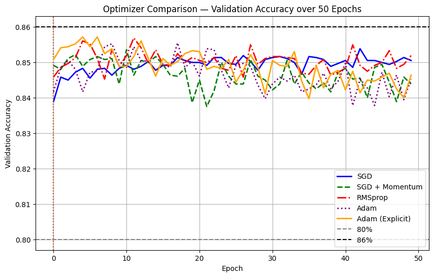

```python
histories = {
    "SGD": history_sgd,
    "SGD + Momentum": history_momentum,
    "RMSprop": history_rmsprop,
    "Adam": history_adam,
    "Adam (Explicit)": history_adam_explicit
}

colors = ["blue", "green", "red", "purple", "orange"]
styles = ["-", "--", "-.", ":", "-"]

plt.figure(figsize=(10,6))

for (name, history), color, style in zip(histories.items(), colors, styles):

    val_acc = history.history["val_accuracy"]

    plt.plot(
        val_acc,
        label=name,
        color=color,
        linestyle=style,
        linewidth=2
    )

    # Mark first epoch crossing 83%
    for epoch, acc in enumerate(val_acc):
        if acc >= 0.83:
            plt.axvline(
                x=epoch,
                color=color,
                linestyle=":",
                alpha=0.6
            )
            break

# Reference Lines
plt.axhline(0.80, color="gray", linestyle="--", label="80%")
plt.axhline(0.86, color="black", linestyle="--", label="86%")

plt.title("Optimizer Comparison — Validation Accuracy over 50 Epochs")
plt.xlabel("Epoch")
plt.ylabel("Validation Accuracy")
plt.legend()
plt.grid(True)

plt.show()
```

### 1. Vanilla SGD (Stochastic Gradient Descent)

- Uses a fixed learning rate for all parameters.
- Updates weights using only the current gradient.
- Does not adapt the learning rate for different features.
- Converges slowly on high-dimensional datasets such as the Adult Income dataset with one-hot encoded features.

### 2. SGD with Momentum

- Adds a **velocity** term that remembers previous updates.
- Update rule:

$$ v=\beta v-\eta\nabla L $$

- Momentum smooths oscillations and accelerates movement toward the optimum.
- Still uses the same learning rate for every parameter.

### 3. RMSprop

- Maintains a running average of squared gradients.
- Automatically adjusts the learning rate for each parameter.
- Works well when gradients change frequently.
- Usually converges faster than SGD.

### 4. Adam (Adaptive Moment Estimation)

Adam combines:

- **Momentum (First Moment)** → remembers the direction of previous gradients.
- **RMSprop (Second Moment)** → adapts the learning rate for every parameter.

Adam also applies **bias correction** during the initial training steps:

$$ \theta=\theta-\eta\frac{\hat{m}}{\sqrt{\hat{v}}+\epsilon} $$

where:

- **m** = First Moment (Momentum)
- **v** = Second Moment (Variance)

This makes Adam stable, fast, and efficient even during the early epochs.

### 5. Adam (Explicit Parameters)

The explicit Adam optimizer confirms the default parameters used in Keras:

- Learning Rate = **0.001**
- β₁ = **0.9**
- β₂ = **0.999**

These values match the original Adam paper by **Kingma & Ba (2015)**.

## 7.4 Learning Rate Sensitivity – SGD vs Adam

```python
from tensorflow.keras.optimizers import SGD

learning_rates_sgd = [0.0001, 0.001, 0.01, 0.1]
history_sgd_lr = {}

for lr in learning_rates_sgd:
    model = build_ann(
        input_dim=X_train.shape[1],
        activation="relu",
        initializer="he_normal",
        use_batch_norm=True,
        optimizer=SGD(learning_rate=lr),
        loss="binary_crossentropy"
    )

    history = model.fit(
        X_train,
        y_train,
        epochs=30,
        batch_size=64,
        validation_split=0.1,
        verbose=0
    )

    history_sgd_lr[lr] = history
```

```python
# train adam models
learning_rates_adam = [0.0001, 0.001, 0.01]
history_adam_lr = {}

for lr in learning_rates_adam:
    model = build_ann(
        input_dim=X_train.shape[1],
        activation="relu",
        initializer="he_normal",
        use_batch_norm=True,
        optimizer=Adam(learning_rate=lr),
        loss="binary_crossentropy"
    )

    history = model.fit(
        X_train,
        y_train,
        epochs=30,
        batch_size=64,
        validation_split=0.1,
        verbose=0
    )

    history_adam_lr[lr] = history
```

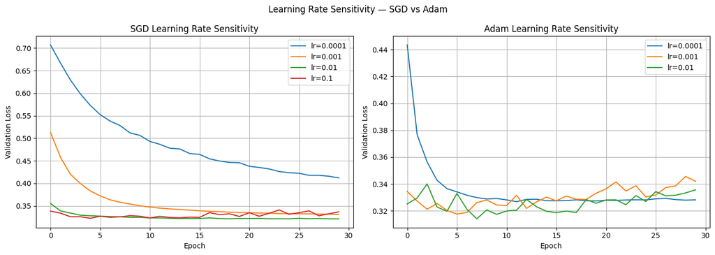

```python
plt.figure(figsize=(14,5))

# SGD
plt.subplot(1,2,1)

for lr, history in history_sgd_lr.items():
    plt.plot(
        history.history["val_loss"],
        label=f"lr={lr}"
    )

plt.title("SGD Learning Rate Sensitivity")
plt.xlabel("Epoch")
plt.ylabel("Validation Loss")
plt.legend()
plt.grid(True)

# Adam
plt.subplot(1,2,2)

for lr, history in history_adam_lr.items():
    plt.plot(
        history.history["val_loss"],
        label=f"lr={lr}"
    )

plt.title("Adam Learning Rate Sensitivity")
plt.xlabel("Epoch")
plt.ylabel("Validation Loss")
plt.legend()
plt.grid(True)

plt.suptitle("Learning Rate Sensitivity — SGD vs Adam")
plt.tight_layout()
plt.show()
```

## Learning Rate Sensitivity: SGD vs Adam

Different learning rates were tested for both **SGD** and **Adam** optimizers.

### SGD

- Very small learning rates (0.0001) result in slow convergence.
- A moderate learning rate (0.01) usually gives the best performance.
- A high learning rate (0.1) may cause unstable training or divergence.

### Adam

- Adam automatically adapts the learning rate for each parameter.
- It performs well across a wider range of learning rates.
- Even when the global learning rate is not optimal, Adam usually converges faster and more stably than SGD.

Therefore, **Adam is less sensitive to learning rate selection**, while **SGD requires careful tuning**.

```python
final_model = build_ann(
    input_dim=X_train.shape[1],
    hidden_units=[128, 64],
    activation="relu",
    initializer="he_normal",
    use_batch_norm=True,
    optimizer="adam",
    loss="binary_crossentropy"
)
```

```python
# Train Final Model
history_final = final_model.fit(
    X_train,
    y_train,
    epochs=80,
    batch_size=64,
    validation_split=0.1,
    class_weight=class_weight,
    verbose=1
)
```

```
509/509 ━━━━━━━━━━━━━━━━━━━━ 4s 4ms/step - accuracy: 0.7918 - loss: 0.4048 - val_accuracy: 0.7858 - val_loss: 0.4243
509/509 ━━━━━━━━━━━━━━━━━━━━ 2s 5ms/step - accuracy: 0.8047 - loss: 0.3784 - val_accuracy: 0.8060 - val_loss: 0.3882
509/509 ━━━━━━━━━━━━━━━━━━━━ 3s 6ms/step - accuracy: 0.8101 - loss: 0.3728 - val_accuracy: 0.7858 - val_loss: 0.4121
509/509 ━━━━━━━━━━━━━━━━━━━━ 2s 4ms/step - accuracy: 0.8116 - loss: 0.3679 - val_accuracy: 0.7955 - val_loss: 0.4096
509/509 ━━━━━━━━━━━━━━━━━━━━ 2s 4ms/step - accuracy: 0.8157 - loss: 0.3631 - val_accuracy: 0.7847 - val_loss: 0.4218
509/509 ━━━━━━━━━━━━━━━━━━━━ 2s 4ms/step - accuracy: 0.8156 - loss: 0.3591 - val_accuracy: 0.8043 - val_loss: 0.3927
509/509 ━━━━━━━━━━━━━━━━━━━━ 2s 4ms/step - accuracy: 0.8167 - loss: 0.3588 - val_accuracy: 0.8085 - val_loss: 0.3809
509/509 ━━━━━━━━━━━━━━━━━━━━ 2s 4ms/step - accuracy: 0.8214 - loss: 0.3498 - val_accuracy: 0.8024 - val_loss: 0.3843
509/509 ━━━━━━━━━━━━━━━━━━━━ 3s 6ms/step - accuracy: 0.8231 - loss: 0.3496 - val_accuracy: 0.8074 - val_loss: 0.3933
509/509 ━━━━━━━━━━━━━━━━━━━━ 3s 6ms/step - accuracy: 0.8206 - loss: 0.3480 - val_accuracy: 0.7927 - val_loss: 0.4007
509/509 ━━━━━━━━━━━━━━━━━━━━ 4s 7ms/step - accuracy: 0.8237 - loss: 0.3441 - val_accuracy: 0.8212 - val_loss: 0.3712
509/509 ━━━━━━━━━━━━━━━━━━━━ 4s 8ms/step - accuracy: 0.8270 - loss: 0.3401 - val_accuracy: 0.7927 - val_loss: 0.4108
509/509 ━━━━━━━━━━━━━━━━━━━━ 4s 6ms/step - accuracy: 0.8267 - loss: 0.3375 - val_accuracy: 0.7875 - val_loss: 0.4105
509/509 ━━━━━━━━━━━━━━━━━━━━ 4s 5ms/step - accuracy: 0.8265 - loss: 0.3370 - val_accuracy: 0.8065 - val_loss: 0.3867
509/509 ━━━━━━━━━━━━━━━━━━━━ 2s 4ms/step - accuracy: 0.8293 - loss: 0.3332 - val_accuracy: 0.7924 - val_loss: 0.4105
509/509 ━━━━━━━━━━━━━━━━━━━━ 2s 4ms/step - accuracy: 0.8262 - loss: 0.3335 - val_accuracy: 0.8004 - val_loss: 0.4111
509/509 ━━━━━━━━━━━━━━━━━━━━ 3s 6ms/step - accuracy: 0.8277 - loss: 0.3309 - val_accuracy: 0.8093 - val_loss: 0.3950
509/509 ━━━━━━━━━━━━━━━━━━━━ 2s 5ms/step - accuracy: 0.8306 - loss: 0.3262 - val_accuracy: 0.8079 - val_loss: 0.3929
509/509 ━━━━━━━━━━━━━━━━━━━━ 2s 4ms/step - accuracy: 0.8301 - loss: 0.3259 - val_accuracy: 0.8049 - val_loss: 0.3956
509/509 ━━━━━━━━━━━━━━━━━━━━ 2s 4ms/step - accuracy: 0.8315 - loss: 0.3245 - val_accuracy: 0.8057 - val_loss: 0.3993
509/509 ━━━━━━━━━━━━━━━━━━━━ 2s 5ms/step - accuracy: 0.8327 - loss: 0.3214 - val_accuracy: 0.8046 - val_loss: 0.4051
509/509 ━━━━━━━━━━━━━━━━━━━━ 2s 4ms/step - accuracy: 0.8365 - loss: 0.3190 - val_accuracy: 0.7930 - val_loss: 0.4227
509/509 ━━━━━━━━━━━━━━━━━━━━ 3s 6ms/step - accuracy: 0.8351 - loss: 0.3169 - val_accuracy: 0.8029 - val_loss: 0.3926
509/509 ━━━━━━━━━━━━━━━━━━━━ 2s 5ms/step - accuracy: 0.8359 - loss: 0.3160 - val_accuracy: 0.7875 - val_loss: 0.4192
509/509 ━━━━━━━━━━━━━━━━━━━━ 2s 4ms/step - accuracy: 0.8376 - loss: 0.3151 - val_accuracy: 0.8065 - val_loss: 0.4002
509/509 ━━━━━━━━━━━━━━━━━━━━ 2s 4ms/step - accuracy: 0.8354 - loss: 0.3130 - val_accuracy: 0.8032 - val_loss: 0.4101
509/509 ━━━━━━━━━━━━━━━━━━━━ 2s 5ms/step - accuracy: 0.8385 - loss: 0.3109 - val_accuracy: 0.7966 - val_loss: 0.4168
509/509 ━━━━━━━━━━━━━━━━━━━━ 2s 4ms/step - accuracy: 0.8371 - loss: 0.3104 - val_accuracy: 0.8132 - val_loss: 0.3946
509/509 ━━━━━━━━━━━━━━━━━━━━ 3s 6ms/step - accuracy: 0.8379 - loss: 0.3085 - val_accuracy: 0.7993 - val_loss: 0.4300
509/509 ━━━━━━━━━━━━━━━━━━━━ 2s 4ms/step - accuracy: 0.8391 - loss: 0.3086 - val_accuracy: 0.8082 - val_loss: 0.4088
509/509 ━━━━━━━━━━━━━━━━━━━━ 2s 4ms/step - accuracy: 0.8387 - loss: 0.3066 - val_accuracy: 0.8071 - val_loss: 0.4133
509/509 ━━━━━━━━━━━━━━━━━━━━ 2s 4ms/step - accuracy: 0.8383 - loss: 0.3055 - val_accuracy: 0.8082 - val_loss: 0.3964
509/509 ━━━━━━━━━━━━━━━━━━━━ 2s 4ms/step - accuracy: 0.8399 - loss: 0.3030 - val_accuracy: 0.8098 - val_loss: 0.4014
509/509 ━━━━━━━━━━━━━━━━━━━━ 2s 5ms/step - accuracy: 0.8411 - loss: 0.3027 - val_accuracy: 0.7957 - val_loss: 0.4194
509/509 ━━━━━━━━━━━━━━━━━━━━ 3s 6ms/step - accuracy: 0.8410 - loss: 0.3022 - val_accuracy: 0.7985 - val_loss: 0.4196
509/509 ━━━━━━━━━━━━━━━━━━━━ 2s 4ms/step - accuracy: 0.8414 - loss: 0.3003 - val_accuracy: 0.7982 - val_loss: 0.4130
509/509 ━━━━━━━━━━━━━━━━━━━━ 2s 4ms/step - accuracy: 0.8425 - loss: 0.3007 - val_accuracy: 0.7866 - val_loss: 0.4421
509/509 ━━━━━━━━━━━━━━━━━━━━ 2s 4ms/step - accuracy: 0.8429 - loss: 0.2985 - val_accuracy: 0.8035 - val_loss: 0.4159
509/509 ━━━━━━━━━━━━━━━━━━━━ 2s 4ms/step - accuracy: 0.8445 - loss: 0.2980 - val_accuracy: 0.8085 - val_loss: 0.4076
509/509 ━━━━━━━━━━━━━━━━━━━━ 2s 5ms/step - accuracy: 0.8453 - loss: 0.2969 - val_accuracy: 0.7963 - val_loss: 0.4226
```

[output cut: 25 more lines]

```
509/509 ━━━━━━━━━━━━━━━━━━━━ 2s 4ms/step - accuracy: 0.8510 - loss: 0.2801 - val_accuracy: 0.8032 - val_loss: 0.4439
509/509 ━━━━━━━━━━━━━━━━━━━━ 2s 4ms/step - accuracy: 0.8535 - loss: 0.2785 - val_accuracy: 0.7993 - val_loss: 0.4384
509/509 ━━━━━━━━━━━━━━━━━━━━ 2s 4ms/step - accuracy: 0.8552 - loss: 0.2747 - val_accuracy: 0.8004 - val_loss: 0.4561
509/509 ━━━━━━━━━━━━━━━━━━━━ 2s 4ms/step - accuracy: 0.8534 - loss: 0.2756 - val_accuracy: 0.7922 - val_loss: 0.4679
509/509 ━━━━━━━━━━━━━━━━━━━━ 2s 4ms/step - accuracy: 0.8565 - loss: 0.2736 - val_accuracy: 0.8109 - val_loss: 0.4449
509/509 ━━━━━━━━━━━━━━━━━━━━ 3s 6ms/step - accuracy: 0.8542 - loss: 0.2753 - val_accuracy: 0.8123 - val_loss: 0.4277
509/509 ━━━━━━━━━━━━━━━━━━━━ 4s 4ms/step - accuracy: 0.8547 - loss: 0.2733 - val_accuracy: 0.8024 - val_loss: 0.4582
509/509 ━━━━━━━━━━━━━━━━━━━━ 2s 4ms/step - accuracy: 0.8549 - loss: 0.2746 - val_accuracy: 0.8098 - val_loss: 0.4369
509/509 ━━━━━━━━━━━━━━━━━━━━ 2s 4ms/step - accuracy: 0.8553 - loss: 0.2724 - val_accuracy: 0.7908 - val_loss: 0.4845
509/509 ━━━━━━━━━━━━━━━━━━━━ 2s 4ms/step - accuracy: 0.8564 - loss: 0.2721 - val_accuracy: 0.8074 - val_loss: 0.4429
509/509 ━━━━━━━━━━━━━━━━━━━━ 3s 6ms/step - accuracy: 0.8564 - loss: 0.2728 - val_accuracy: 0.7988 - val_loss: 0.4530
509/509 ━━━━━━━━━━━━━━━━━━━━ 2s 4ms/step - accuracy: 0.8553 - loss: 0.2704 - val_accuracy: 0.7899 - val_loss: 0.4738
509/509 ━━━━━━━━━━━━━━━━━━━━ 3s 5ms/step - accuracy: 0.8552 - loss: 0.2712 - val_accuracy: 0.8040 - val_loss: 0.4624
509/509 ━━━━━━━━━━━━━━━━━━━━ 2s 5ms/step - accuracy: 0.8568 - loss: 0.2715 - val_accuracy: 0.8085 - val_loss: 0.4505
509/509 ━━━━━━━━━━━━━━━━━━━━ 2s 5ms/step - accuracy: 0.8564 - loss: 0.2681 - val_accuracy: 0.7960 - val_loss: 0.4707
```

```python
# Evaluate Final Model
from sklearn.metrics import accuracy_score, precision_score, recall_score, f1_score, roc_auc_score

# Prediction
y_prob = final_model.predict(X_test).flatten()
y_pred = (y_prob > 0.5).astype(int)

results = pd.DataFrame({
    "Metric": [
        "Accuracy",
        "Precision",
        "Recall",
        "F1-Score",
        "ROC-AUC"
    ],
    "Value": [
        accuracy_score(y_test, y_pred),
        precision_score(y_test, y_pred),
        recall_score(y_test, y_pred),
        f1_score(y_test, y_pred),
        roc_auc_score(y_test, y_prob)
    ]
})

results
```

```
283/283 ━━━━━━━━━━━━━━━━━━━━ 1s 2ms/step
```

|  | Metric | Value |
| --- | --- | --- |
| 0 | Accuracy | 0.788502 |
| 1 | Precision | 0.548142 |
| 2 | Recall | 0.835415 |
| 3 | F1-Score | 0.661954 |
| 4 | ROC-AUC | 0.886607 |

## Final ANN Configuration

The final model is evaluated using:

- Accuracy
- Precision
- Recall
- F1-Score
- ROC-AUC

These metrics provide a complete assessment of the model's classification performance.

## 7.6 Full Results Comparison Table

```python
from sklearn.metrics import accuracy_score, precision_score, recall_score, f1_score, roc_auc_score

# Seven models tracked across the project, evaluated on the held-out test set
model_registry = [
    ("Baseline",         model_base,       "ReLU", "Glorot Uniform", "BCE",          "No",  "Adam"),
    ("Best Activation",  model_elu,        "ELU",  "Glorot Uniform", "BCE",          "No",  "Adam"),
    ("Best Initializer", model_he_normal,  "ReLU", "He Normal",      "BCE",          "No",  "Adam"),
    ("Weighted BCE",     model_wbce,       "ReLU", "He Normal",      "Weighted BCE", "No",  "Adam"),
    ("Focal Loss",       model_focal,      "ReLU", "He Normal",      "Focal Loss",   "No",  "Adam"),
    ("BatchNorm",        model_bn,         "ReLU", "He Normal",      "BCE",          "Yes", "Adam"),
    ("Final Combined",   final_model,      "ReLU", "He Normal",      "Weighted BCE", "Yes", "Adam"),
]

rows = []
for name, mdl, activation, initializer, loss_name, bn_flag, opt_name in model_registry:
    y_prob = mdl.predict(X_test, verbose=0).flatten()
    y_pred = (y_prob > 0.5).astype(int)
    rows.append({
        "Model": name,
        "Activation": activation,
        "Initializer": initializer,
        "Loss": loss_name,
        "BatchNorm": bn_flag,
        "Optimizer": opt_name,
        "Test Accuracy": accuracy_score(y_test, y_pred),
        "Precision": precision_score(y_test, y_pred),
        "Recall": recall_score(y_test, y_pred),
        "F1(1)": f1_score(y_test, y_pred),
        "ROC-AUC": roc_auc_score(y_test, y_prob),
    })

results = pd.DataFrame(rows)
results
```

|  | Model | Activation | Initializer | Loss | BatchNorm | Optimizer | Test Accuracy | Precision | Recall | F1(1) | ROC-AUC |
| --- | --- | --- | --- | --- | --- | --- | --- | --- | --- | --- | --- |
| 0 | Baseline | ReLU | Glorot Uniform | BCE | No | Adam | 0.844776 | 0.707426 | 0.637377 | 0.670577 | 0.890354 |
| 1 | Best Activation | ELU | Glorot Uniform | BCE | No | Adam | 0.850636 | 0.728814 | 0.632917 | 0.677489 | 0.906691 |
| 2 | Best Initializer | ReLU | He Normal | BCE | No | Adam | 0.838585 | 0.708200 | 0.593220 | 0.645631 | 0.886973 |
| 3 | Weighted BCE | ReLU | He Normal | Weighted BCE | No | Adam | 0.786622 | 0.544521 | 0.851026 | 0.664114 | 0.890985 |
| 4 | Focal Loss | ReLU | He Normal | Focal Loss | No | Adam | 0.826645 | 0.764937 | 0.433988 | 0.553785 | 0.884292 |
| 5 | BatchNorm | ReLU | He Normal | BCE | Yes | Adam | 0.842676 | 0.722675 | 0.592774 | 0.651311 | 0.897308 |
| 6 | Final Combined | ReLU | He Normal | Weighted BCE | Yes | Adam | 0.788502 | 0.548142 | 0.835415 | 0.661954 | 0.886607 |

```python
results.style.highlight_max(
    subset=["F1(1)", "ROC-AUC"],
    color="#ffcccc"
)
```

|  | Model | Activation | Initializer | Loss | BatchNorm | Optimizer | Test Accuracy | Precision | Recall | F1(1) | ROC-AUC |
| --- | --- | --- | --- | --- | --- | --- | --- | --- | --- | --- | --- |
| 0 | Baseline | ReLU | Glorot Uniform | BCE | No | Adam | 0.844776 | 0.707426 | 0.637377 | 0.670577 | 0.890354 |
| 1 | Best Activation | ELU | Glorot Uniform | BCE | No | Adam | 0.850636 | 0.728814 | 0.632917 | 0.677489 | 0.906691 |
| 2 | Best Initializer | ReLU | He Normal | BCE | No | Adam | 0.838585 | 0.708200 | 0.593220 | 0.645631 | 0.886973 |
| 3 | Weighted BCE | ReLU | He Normal | Weighted BCE | No | Adam | 0.786622 | 0.544521 | 0.851026 | 0.664114 | 0.890985 |
| 4 | Focal Loss | ReLU | He Normal | Focal Loss | No | Adam | 0.826645 | 0.764937 | 0.433988 | 0.553785 | 0.884292 |
| 5 | BatchNorm | ReLU | He Normal | BCE | Yes | Adam | 0.842676 | 0.722675 | 0.592774 | 0.651311 | 0.897308 |
| 6 | Final Combined | ReLU | He Normal | Weighted BCE | Yes | Adam | 0.788502 | 0.548142 | 0.835415 | 0.661954 | 0.886607 |

```
283/283 ━━━━━━━━━━━━━━━━━━━━ 1s 2ms/step
283/283 ━━━━━━━━━━━━━━━━━━━━ 0s 2ms/step
283/283 ━━━━━━━━━━━━━━━━━━━━ 1s 2ms/step
```

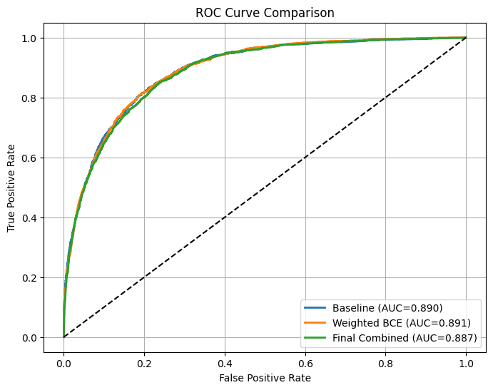

```python
from sklearn.metrics import roc_curve, roc_auc_score

models = {
    "Baseline": model_base,
    "Weighted BCE": model_wbce,
    "Final Combined": final_model
}

plt.figure(figsize=(8,6))

for name, model in models.items():

    y_prob = model.predict(X_test).flatten()

    fpr, tpr, _ = roc_curve(y_test, y_prob)

    auc = roc_auc_score(y_test, y_prob)

    plt.plot(
        fpr,
        tpr,
        linewidth=2,
        label=f"{name} (AUC={auc:.3f})"
    )

plt.plot([0,1],[0,1],"k--")

plt.xlabel("False Positive Rate")
plt.ylabel("True Positive Rate")
plt.title("ROC Curve Comparison")
plt.legend()

plt.grid(True)
plt.show()
```

## Full Results Comparison

The table summarizes the performance of all major models developed throughout the project.

The comparison includes:

- Baseline ANN
- Best Activation Function
- Best Weight Initializer
- Weighted Binary Cross-Entropy
- Focal Loss
- Batch Normalization Model
- Final Combined Model

The best values for **F1-score** and **ROC-AUC** are highlighted.

The ROC curve compares the classification performance of the Baseline model, Weighted BCE model, and Final Combined model.

A larger ROC-AUC indicates better discrimination between the two income classes.